# examples_func_intro

Look up [inverse functions](https://en.wikipedia.org/wiki/Inverse_function).

Find the correct point on the graph where $f(x)=8$.

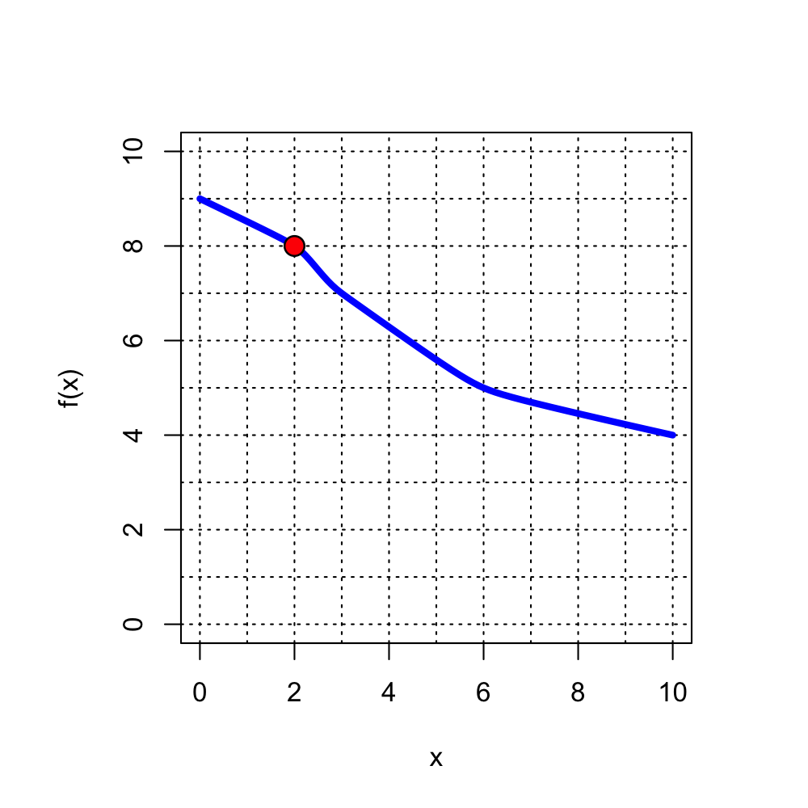

$$f(2)=8$$

Thus,

$$f^{-1}(8) ~=~ 2$$

A one-to-one function $f$ is graphed below.

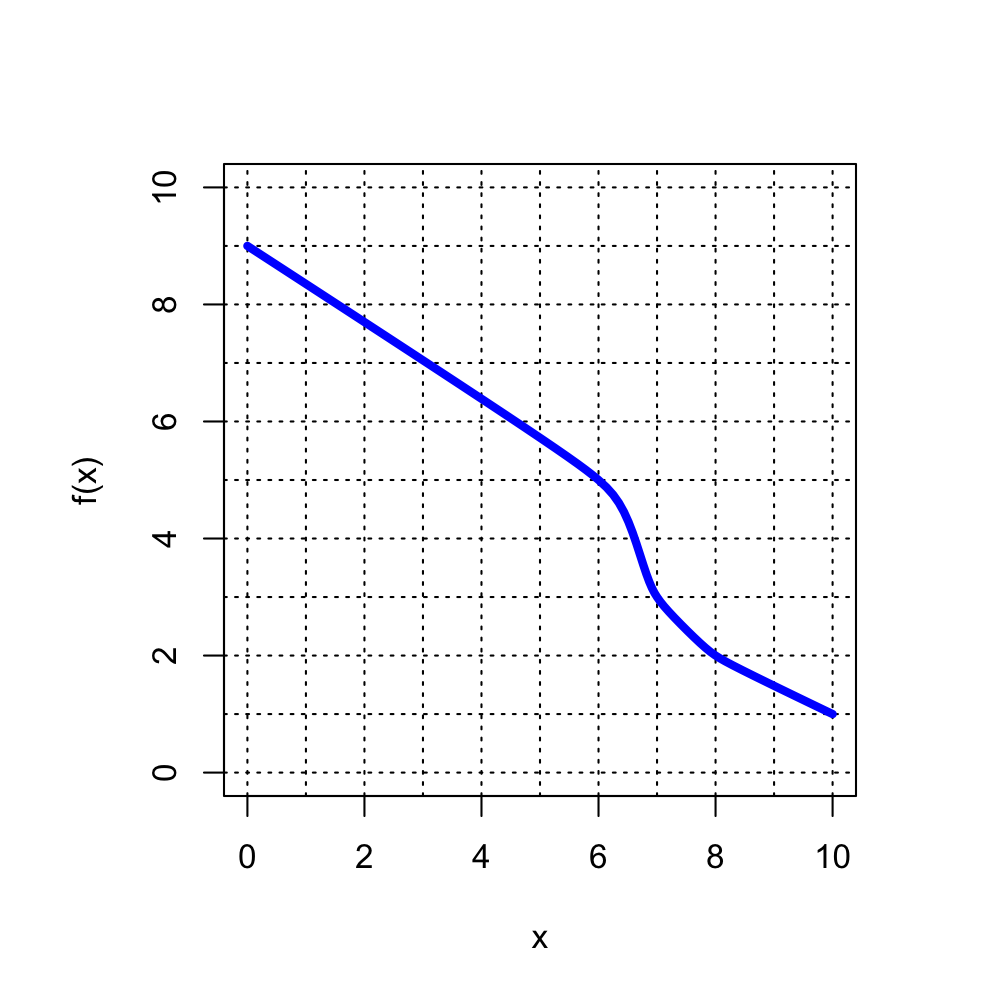

- If $f(x)=3$, then find $x$. In other words, evaluate $f^{-1}(3)$.

Look up [inverse functions](https://en.wikipedia.org/wiki/Inverse_function).

Find the correct point on the graph where $f(x)=3$.

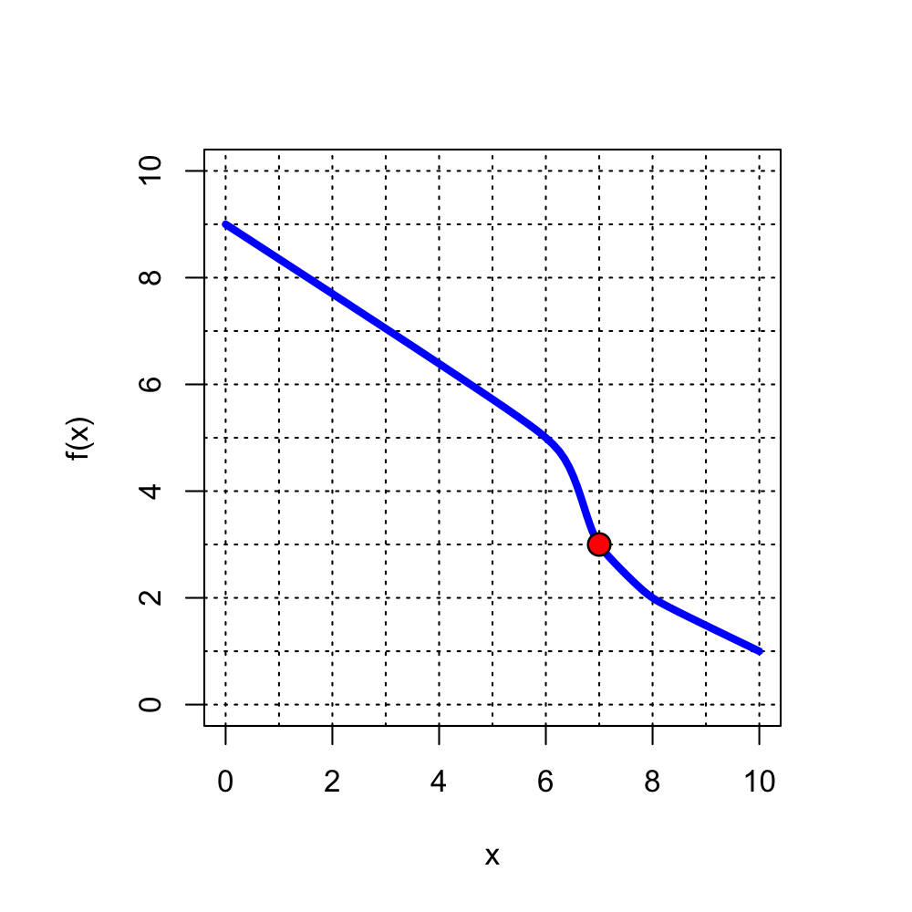

$$f(7)=3$$

Thus,

$$f^{-1}(3) ~=~ 7$$

A one-to-one function $f$ is graphed below.

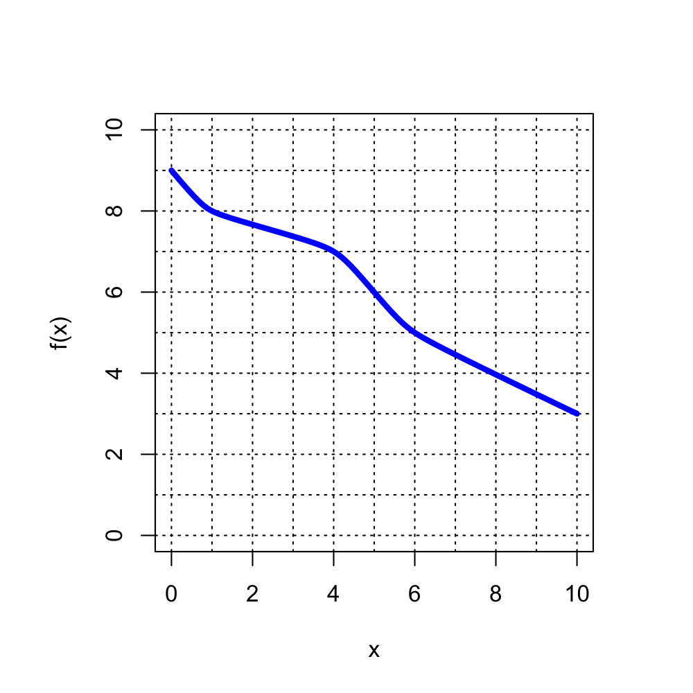

- If $f(x)=8$, then find $x$. In other words, evaluate $f^{-1}(8)$.

Look up [inverse functions](https://en.wikipedia.org/wiki/Inverse_function).

Find the correct point on the graph where $f(x)=8$.

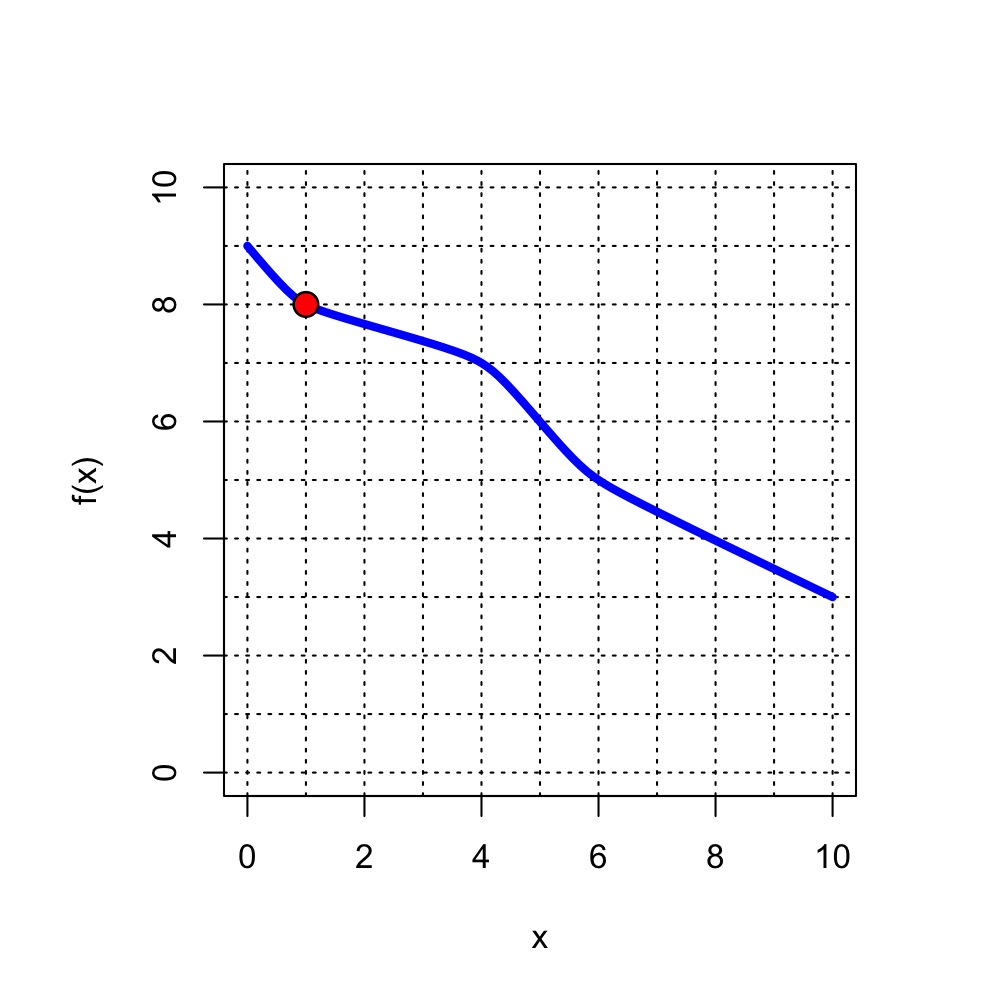

$$f(1)=8$$

Thus,

$$f^{-1}(8) ~=~ 1$$

A one-to-one function $f$ is graphed below.

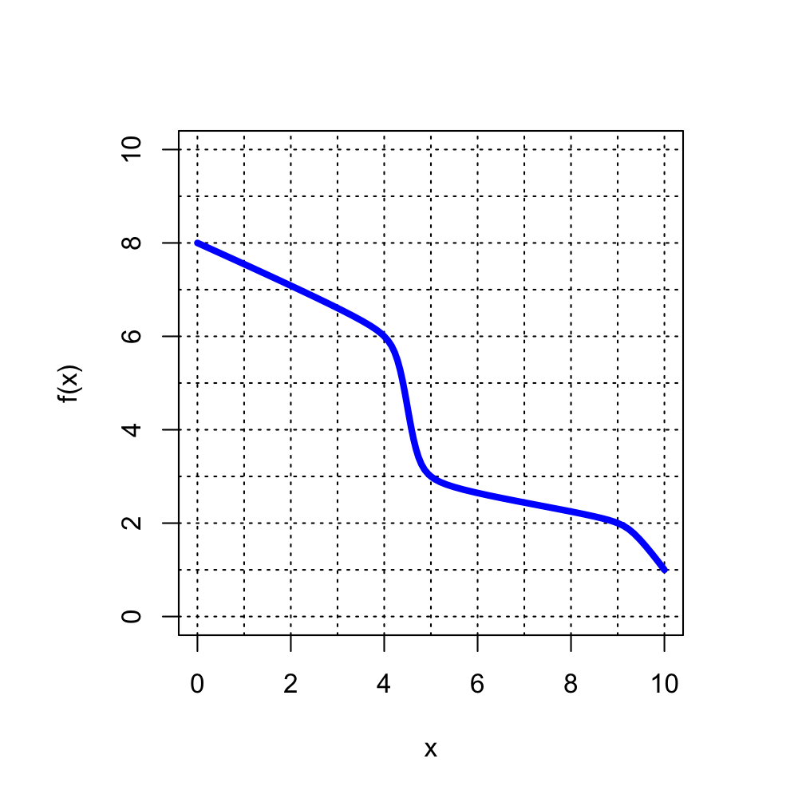

- If $f(x)=3$, then find $x$. In other words, evaluate $f^{-1}(3)$.

Look up [inverse functions](https://en.wikipedia.org/wiki/Inverse_function).

Find the correct point on the graph where $f(x)=3$.

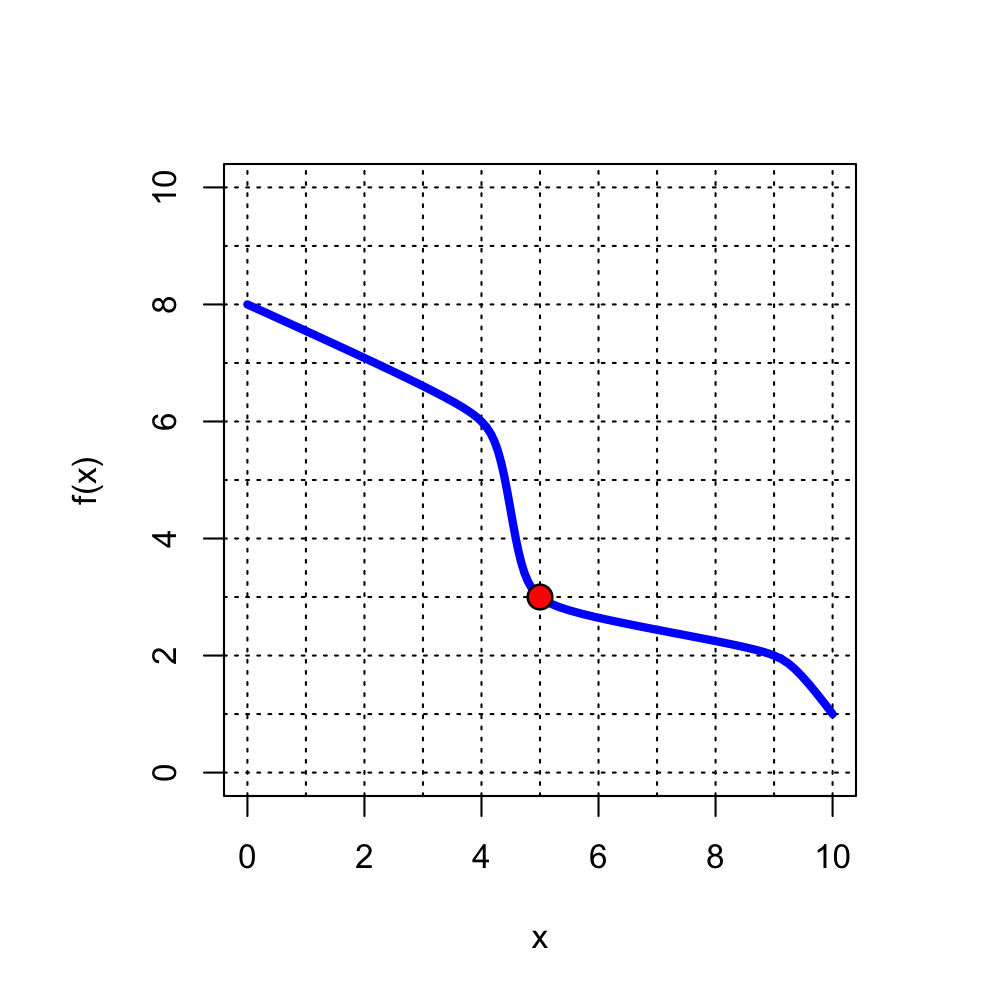

$$f(5)=3$$

Thus,

$$f^{-1}(3) ~=~ 5$$

A one-to-one function $f$ is graphed below.

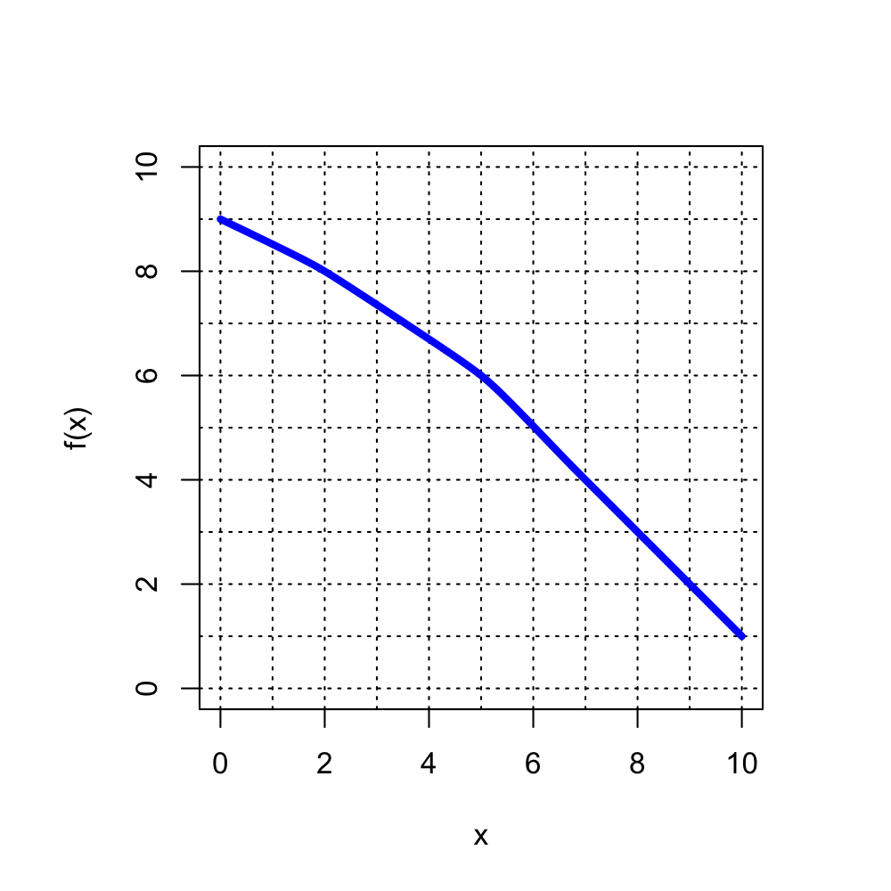

- If $f(x)=4$, then find $x$. In other words, evaluate $f^{-1}(4)$.

Look up [inverse functions](https://en.wikipedia.org/wiki/Inverse_function).

Find the correct point on the graph where $f(x)=4$.

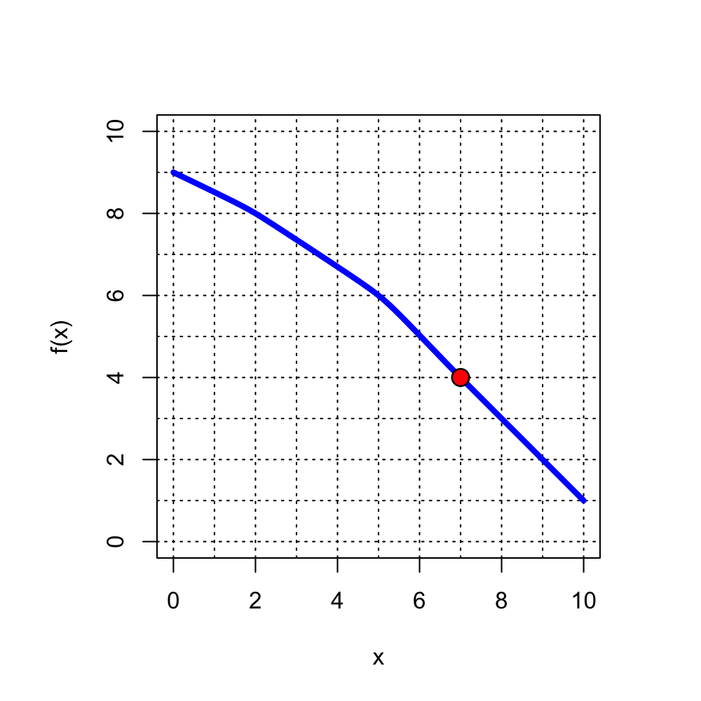

$$f(7)=4$$

Thus,

$$f^{-1}(4) ~=~ 7$$

A one-to-one function $f$ is graphed below.

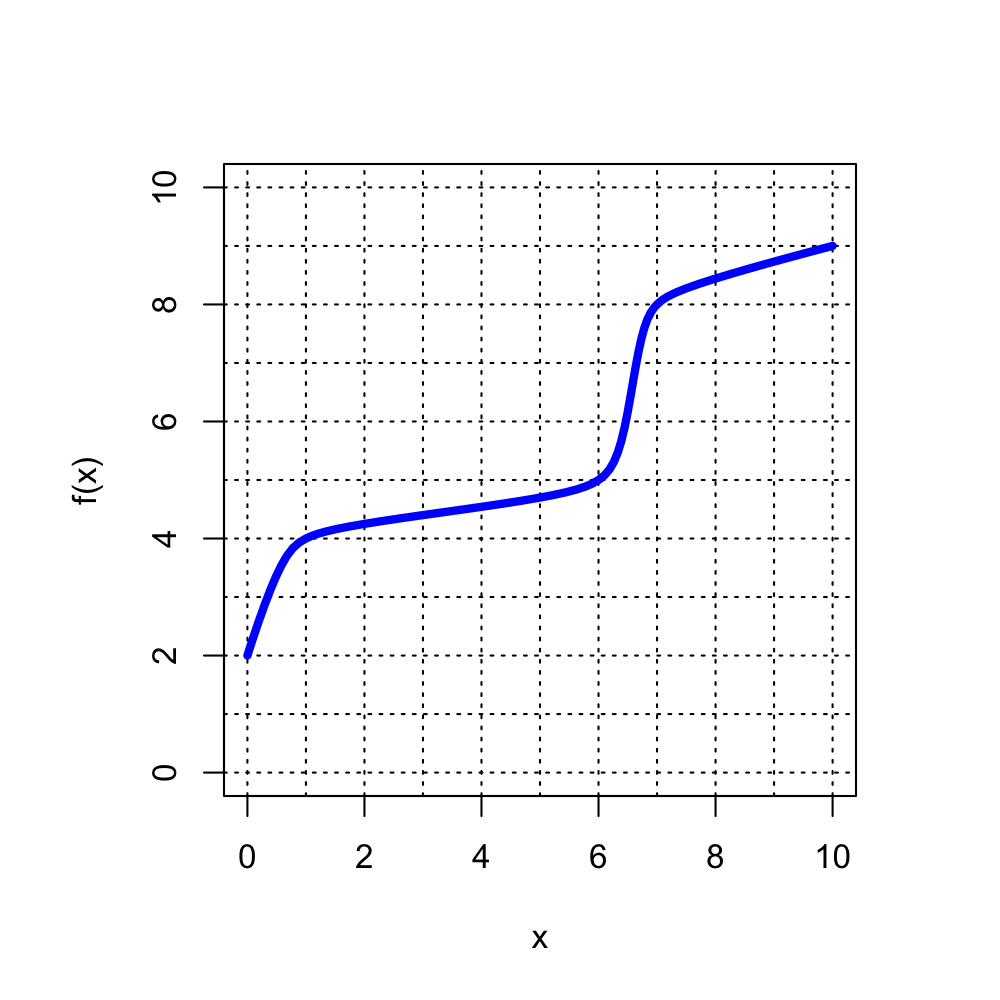

- If $f(x)=5$, then find $x$. In other words, evaluate $f^{-1}(5)$.

Look up [inverse functions](https://en.wikipedia.org/wiki/Inverse_function).

Find the correct point on the graph where $f(x)=5$.

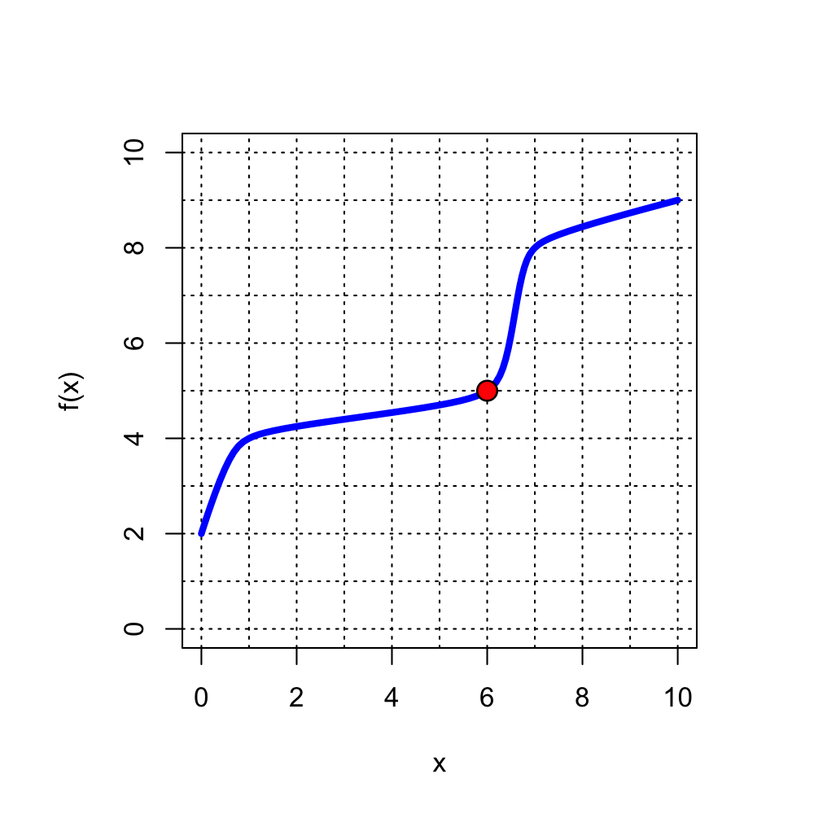

$$f(6)=5$$

Thus,

$$f^{-1}(5) ~=~ 6$$

A one-to-one function $f$ is graphed below.

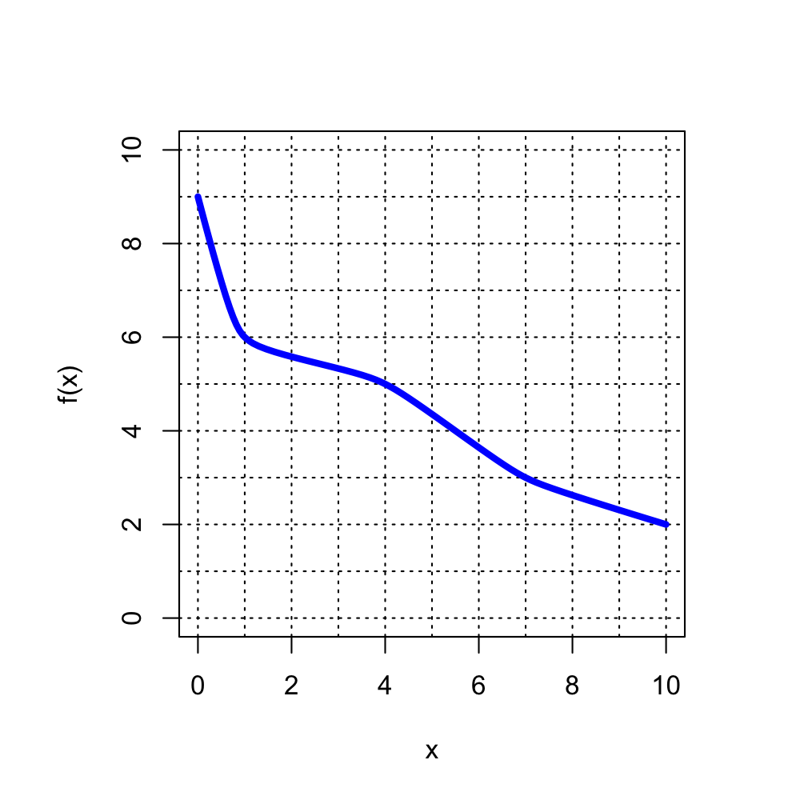

- If $f(x)=3$, then find $x$. In other words, evaluate $f^{-1}(3)$.

Look up [inverse functions](https://en.wikipedia.org/wiki/Inverse_function).

Find the correct point on the graph where $f(x)=3$.

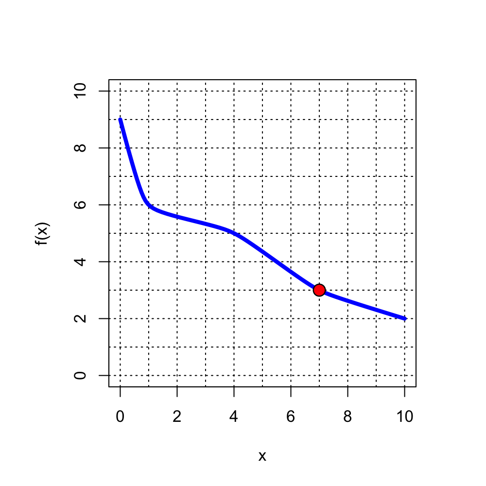

$$f(7)=3$$

Thus,

$$f^{-1}(3) ~=~ 7$$

A one-to-one function $f$ is graphed below.

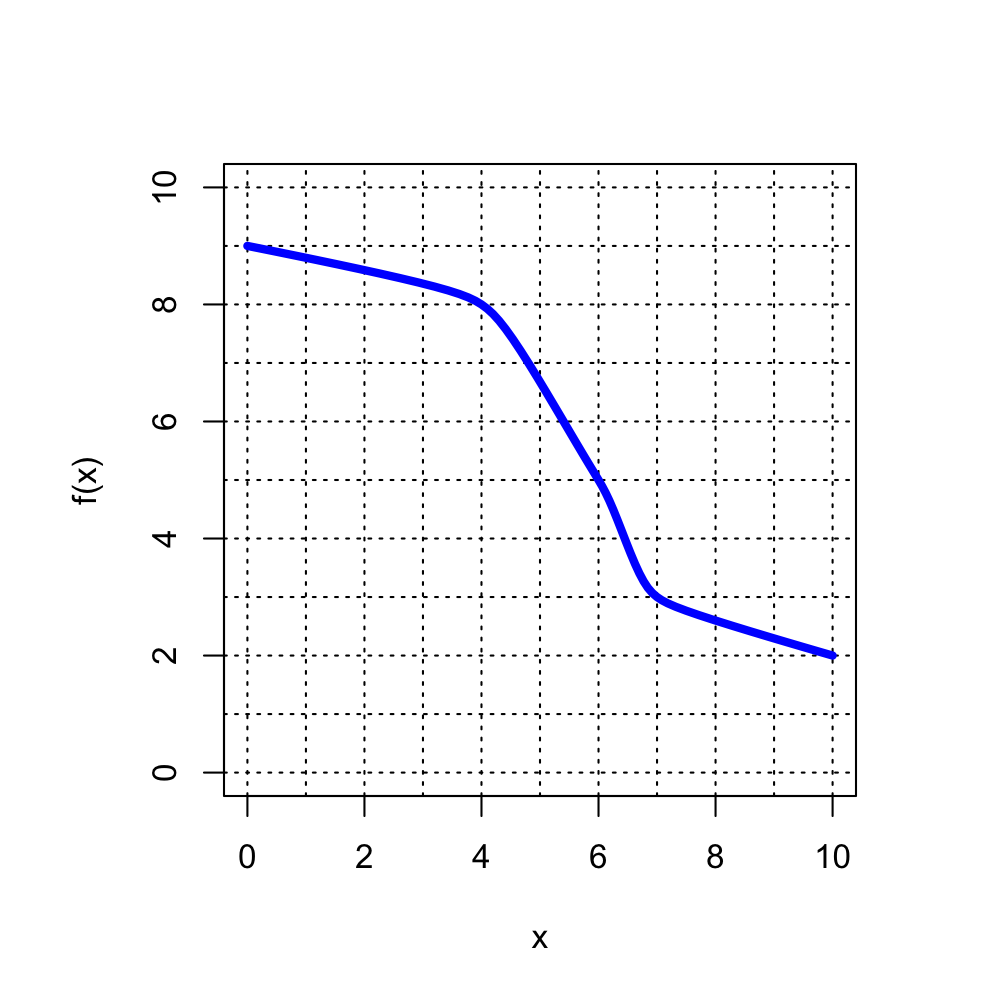

- If $f(x)=8$, then find $x$. In other words, evaluate $f^{-1}(8)$.

Look up [inverse functions](https://en.wikipedia.org/wiki/Inverse_function).

Find the correct point on the graph where $f(x)=8$.

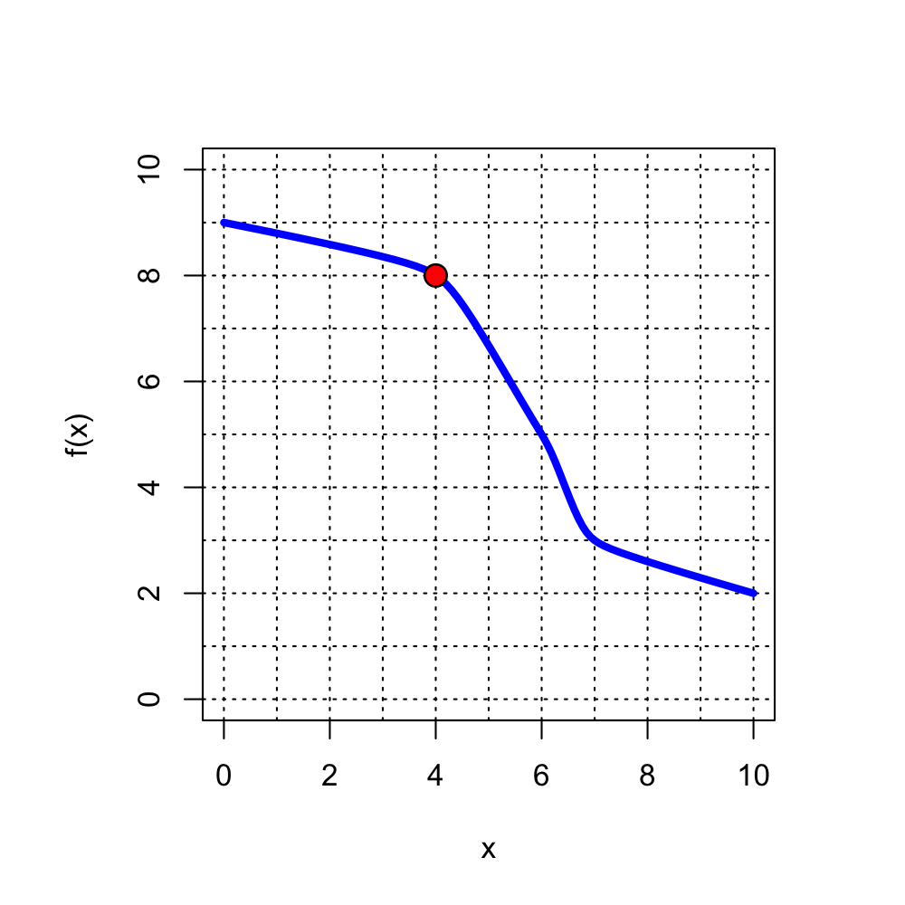

$$f(4)=8$$

Thus,

$$f^{-1}(8) ~=~ 4$$

A one-to-one function $f$ is graphed below.

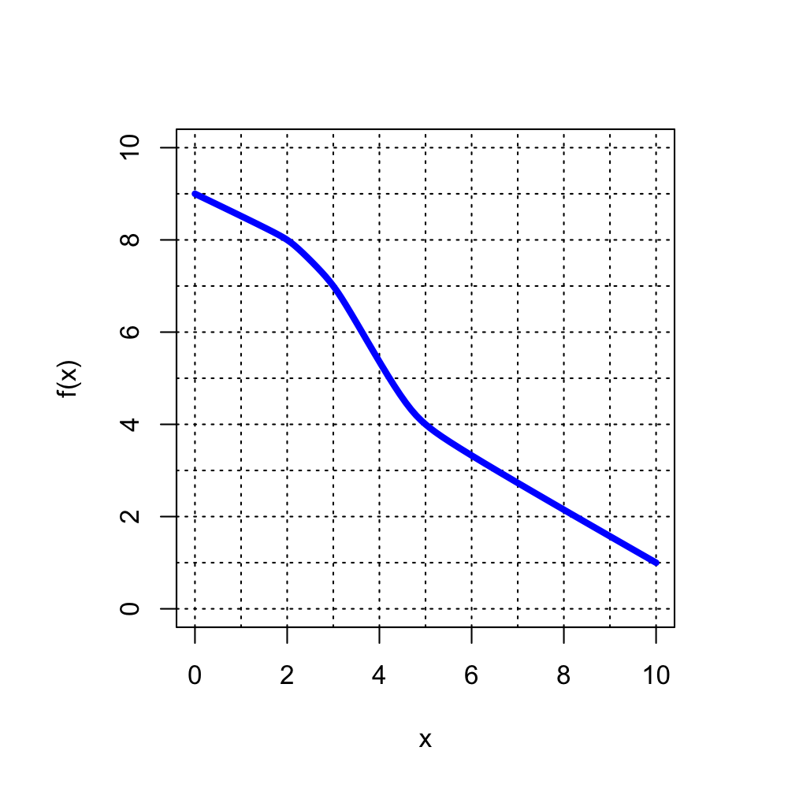

- If $f(x)=8$, then find $x$. In other words, evaluate $f^{-1}(8)$.

Look up [inverse functions](https://en.wikipedia.org/wiki/Inverse_function).

Find the correct point on the graph where $f(x)=8$.

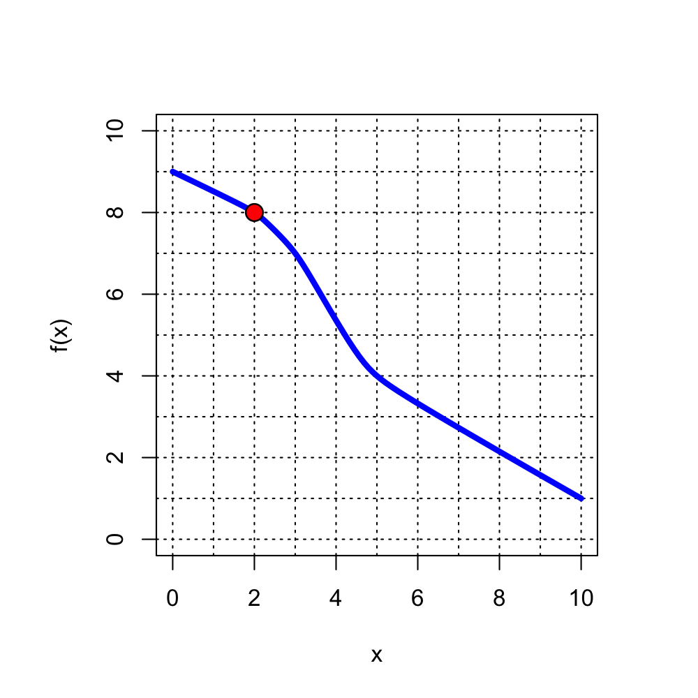

$$f(2)=8$$

Thus,

$$f^{-1}(8) ~=~ 2$$

Let a [one-to-one function](https://en.wikipedia.org/wiki/Injective_function), $f$, be defined by the table below.

| $x$ | $f(x)$ |
| --- | --- |
| 1 | 2 |
| 2 | 5 |
| 3 | 7 |
| 4 | 3 |
| 5 | 1 |
| 6 | 4 |
| 7 | 6 |

Create the [inverse function's](https://en.wikipedia.org/wiki/Inverse_function) table.

| $x$ | $f^{-1}(x)$ |
| --- | --- |
| 1 |  |
| 2 |  |
| 3 |  |
| 4 |  |
| 5 |  |
| 6 |  |
| 7 |  |

The inverse function $f^{-1}$ is defined by the table below.

| $x$ | $f^{-1}(x)$ |
| --- | --- |
| 1 | 5 |
| 2 | 1 |
| 3 | 4 |
| 4 | 6 |
| 5 | 2 |
| 6 | 7 |
| 7 | 3 |

Notice, you just switch the columns of the given $f$ table and then sort by the first column.

Consider the functions $f$, $g$, and $h$ shown below.

| x | f(x) | g(x) | h(x) |
| --- | --- | --- | --- |
| 1 | 5 | 7 | 2 |
| 2 | 9 | 9 | 5 |
| 3 | 7 | 4 | 4 |
| 4 | 1 | 2 | 3 |
| 5 | 6 | 6 | 7 |
| 6 | 2 | 3 | 9 |
| 7 | 4 | 1 | 1 |
| 8 | 8 | 5 | 6 |
| 9 | 3 | 8 | 8 |

Evaluate the [inverse-function](https://en.wikipedia.org/wiki/Inverse_function) expressions below.

- $f^{-1}(6)~=$
- $g^{-1}(5)~=$
- $h^{-1}(4)~=$

First, it must be said that the inverse-function notation is an abomination.

> Inverse function notation, such as $f^{-1}(x)$, is a convention used in mathematics to represent the inverse of a function $f$. While it is widely adopted and understood by mathematicians, it is a source of confusion for some, particularly students learning about inverse functions for the first time. The primary reason for this confusion is the notation's similarity to an exponent. Students may mistakenly interpret $f^{-1}(x)$ as $1/f(x)$ or the reciprocal of the function, rather than the function that "undoes" the action of $f$. This ambiguity necessitates explicit clarification of the distinction between inverse functions and reciprocals when teaching the concept.

To evaluate $f^{-1}(6)$, start in the SECOND COLUMN, and go down to the row where $f=6$. Then, move to the FIRST COLUMN in the same row, to see that $x~=~5$. This tells us that $f^{-1}(6)=5$.

To evaluate $g^{-1}(5)$, start in the THIRD COLUMN, and go down to the row where $g=5$. Then, move to the FIRST COLUMN in the same row, to see that $x~=~8$. This tells us that $g^{-1}(5)=8$.

To evaluate $h^{-1}(4)$, start in the FOURTH COLUMN, and go down to the row where $h=4$. Then, move to the FIRST COLUMN in the same row, to see that $x~=~3$. This tells us that $h^{-1}(4)=3$.

Consider the functions $f$, $g$, and $h$ shown below.

| x | f(x) | g(x) | h(x) |
| --- | --- | --- | --- |
| 1 | 2 | 1 | 9 |
| 2 | 4 | 7 | 4 |
| 3 | 7 | 6 | 5 |
| 4 | 8 | 2 | 7 |
| 5 | 1 | 9 | 6 |
| 6 | 9 | 4 | 1 |
| 7 | 3 | 5 | 3 |
| 8 | 5 | 3 | 8 |
| 9 | 6 | 8 | 2 |

Evaluate the [inverse-function](https://en.wikipedia.org/wiki/Inverse_function) expressions below.

- $f^{-1}(8)~=$
- $g^{-1}(9)~=$
- $h^{-1}(1)~=$

First, it must be said that the inverse-function notation is an abomination.

> Inverse function notation, such as $f^{-1}(x)$, is a convention used in mathematics to represent the inverse of a function $f$. While it is widely adopted and understood by mathematicians, it is a source of confusion for some, particularly students learning about inverse functions for the first time. The primary reason for this confusion is the notation's similarity to an exponent. Students may mistakenly interpret $f^{-1}(x)$ as $1/f(x)$ or the reciprocal of the function, rather than the function that "undoes" the action of $f$. This ambiguity necessitates explicit clarification of the distinction between inverse functions and reciprocals when teaching the concept.

To evaluate $f^{-1}(8)$, start in the SECOND COLUMN, and go down to the row where $f=8$. Then, move to the FIRST COLUMN in the same row, to see that $x~=~4$. This tells us that $f^{-1}(8)=4$.

To evaluate $g^{-1}(9)$, start in the THIRD COLUMN, and go down to the row where $g=9$. Then, move to the FIRST COLUMN in the same row, to see that $x~=~5$. This tells us that $g^{-1}(9)=5$.

To evaluate $h^{-1}(1)$, start in the FOURTH COLUMN, and go down to the row where $h=1$. Then, move to the FIRST COLUMN in the same row, to see that $x~=~6$. This tells us that $h^{-1}(1)=6$.

Consider the functions $f$, $g$, and $h$ shown below.

| x | f(x) | g(x) | h(x) |
| --- | --- | --- | --- |
| 1 | 4 | 6 | 8 |
| 2 | 7 | 2 | 3 |
| 3 | 1 | 3 | 2 |
| 4 | 9 | 7 | 1 |
| 5 | 6 | 8 | 6 |
| 6 | 5 | 1 | 4 |
| 7 | 2 | 4 | 5 |
| 8 | 3 | 9 | 9 |
| 9 | 8 | 5 | 7 |

Evaluate the [inverse-function](https://en.wikipedia.org/wiki/Inverse_function) expressions below.

- $f^{-1}(5)~=$
- $g^{-1}(2)~=$
- $h^{-1}(4)~=$

First, it must be said that the inverse-function notation is an abomination.

> Inverse function notation, such as $f^{-1}(x)$, is a convention used in mathematics to represent the inverse of a function $f$. While it is widely adopted and understood by mathematicians, it is a source of confusion for some, particularly students learning about inverse functions for the first time. The primary reason for this confusion is the notation's similarity to an exponent. Students may mistakenly interpret $f^{-1}(x)$ as $1/f(x)$ or the reciprocal of the function, rather than the function that "undoes" the action of $f$. This ambiguity necessitates explicit clarification of the distinction between inverse functions and reciprocals when teaching the concept.

To evaluate $f^{-1}(5)$, start in the SECOND COLUMN, and go down to the row where $f=5$. Then, move to the FIRST COLUMN in the same row, to see that $x~=~6$. This tells us that $f^{-1}(5)=6$.

To evaluate $g^{-1}(2)$, start in the THIRD COLUMN, and go down to the row where $g=2$. Then, move to the FIRST COLUMN in the same row, to see that $x~=~2$. This tells us that $g^{-1}(2)=2$.

To evaluate $h^{-1}(4)$, start in the FOURTH COLUMN, and go down to the row where $h=4$. Then, move to the FIRST COLUMN in the same row, to see that $x~=~6$. This tells us that $h^{-1}(4)=6$.

Consider the functions $f$, $g$, and $h$ shown below.

| x | f(x) | g(x) | h(x) |
| --- | --- | --- | --- |
| 1 | 7 | 6 | 1 |
| 2 | 4 | 5 | 9 |
| 3 | 5 | 4 | 4 |
| 4 | 3 | 3 | 8 |
| 5 | 1 | 7 | 6 |
| 6 | 8 | 2 | 3 |
| 7 | 6 | 1 | 5 |
| 8 | 9 | 9 | 2 |
| 9 | 2 | 8 | 7 |

Evaluate the [inverse-function](https://en.wikipedia.org/wiki/Inverse_function) expressions below.

- $f^{-1}(5)~=$
- $g^{-1}(9)~=$
- $h^{-1}(4)~=$

First, it must be said that the inverse-function notation is an abomination.

> Inverse function notation, such as $f^{-1}(x)$, is a convention used in mathematics to represent the inverse of a function $f$. While it is widely adopted and understood by mathematicians, it is a source of confusion for some, particularly students learning about inverse functions for the first time. The primary reason for this confusion is the notation's similarity to an exponent. Students may mistakenly interpret $f^{-1}(x)$ as $1/f(x)$ or the reciprocal of the function, rather than the function that "undoes" the action of $f$. This ambiguity necessitates explicit clarification of the distinction between inverse functions and reciprocals when teaching the concept.

To evaluate $f^{-1}(5)$, start in the SECOND COLUMN, and go down to the row where $f=5$. Then, move to the FIRST COLUMN in the same row, to see that $x~=~3$. This tells us that $f^{-1}(5)=3$.

To evaluate $g^{-1}(9)$, start in the THIRD COLUMN, and go down to the row where $g=9$. Then, move to the FIRST COLUMN in the same row, to see that $x~=~8$. This tells us that $g^{-1}(9)=8$.

To evaluate $h^{-1}(4)$, start in the FOURTH COLUMN, and go down to the row where $h=4$. Then, move to the FIRST COLUMN in the same row, to see that $x~=~3$. This tells us that $h^{-1}(4)=3$.

Consider the functions $f$, $g$, and $h$ shown below.

| x | f(x) | g(x) | h(x) |
| --- | --- | --- | --- |
| 1 | 8 | 4 | 3 |
| 2 | 5 | 8 | 8 |
| 3 | 6 | 7 | 5 |
| 4 | 9 | 5 | 9 |
| 5 | 1 | 1 | 6 |
| 6 | 3 | 9 | 7 |
| 7 | 4 | 6 | 1 |
| 8 | 7 | 3 | 4 |
| 9 | 2 | 2 | 2 |

Evaluate the [inverse-function](https://en.wikipedia.org/wiki/Inverse_function) expressions below.

- $f^{-1}(2)~=$
- $g^{-1}(7)~=$
- $h^{-1}(4)~=$

First, it must be said that the inverse-function notation is an abomination.

> Inverse function notation, such as $f^{-1}(x)$, is a convention used in mathematics to represent the inverse of a function $f$. While it is widely adopted and understood by mathematicians, it is a source of confusion for some, particularly students learning about inverse functions for the first time. The primary reason for this confusion is the notation's similarity to an exponent. Students may mistakenly interpret $f^{-1}(x)$ as $1/f(x)$ or the reciprocal of the function, rather than the function that "undoes" the action of $f$. This ambiguity necessitates explicit clarification of the distinction between inverse functions and reciprocals when teaching the concept.

To evaluate $f^{-1}(2)$, start in the SECOND COLUMN, and go down to the row where $f=2$. Then, move to the FIRST COLUMN in the same row, to see that $x~=~9$. This tells us that $f^{-1}(2)=9$.

To evaluate $g^{-1}(7)$, start in the THIRD COLUMN, and go down to the row where $g=7$. Then, move to the FIRST COLUMN in the same row, to see that $x~=~3$. This tells us that $g^{-1}(7)=3$.

To evaluate $h^{-1}(4)$, start in the FOURTH COLUMN, and go down to the row where $h=4$. Then, move to the FIRST COLUMN in the same row, to see that $x~=~8$. This tells us that $h^{-1}(4)=8$.

Let a [one-to-one function](https://en.wikipedia.org/wiki/Injective_function), $f$, be defined by the table below.

| $x$ | $f(x)$ |
| --- | --- |
| 1 | 7 |
| 2 | 1 |
| 3 | 4 |
| 4 | 6 |
| 5 | 2 |
| 6 | 3 |
| 7 | 5 |

Create the [inverse function's](https://en.wikipedia.org/wiki/Inverse_function) table.

| $x$ | $f^{-1}(x)$ |
| --- | --- |
| 1 |  |
| 2 |  |
| 3 |  |
| 4 |  |
| 5 |  |
| 6 |  |
| 7 |  |

The inverse function $f^{-1}$ is defined by the table below.

| $x$ | $f^{-1}(x)$ |
| --- | --- |
| 1 | 2 |
| 2 | 5 |
| 3 | 6 |
| 4 | 3 |
| 5 | 7 |
| 6 | 4 |
| 7 | 1 |

Notice, you just switch the columns of the given $f$ table and then sort by the first column.

Let a [one-to-one function](https://en.wikipedia.org/wiki/Injective_function), $f$, be defined by the table below.

| $x$ | $f(x)$ |
| --- | --- |
| 1 | 7 |
| 2 | 4 |
| 3 | 6 |
| 4 | 5 |
| 5 | 1 |
| 6 | 2 |
| 7 | 3 |

Create the [inverse function's](https://en.wikipedia.org/wiki/Inverse_function) table.

| $x$ | $f^{-1}(x)$ |
| --- | --- |
| 1 |  |
| 2 |  |
| 3 |  |
| 4 |  |
| 5 |  |
| 6 |  |
| 7 |  |

The inverse function $f^{-1}$ is defined by the table below.

| $x$ | $f^{-1}(x)$ |
| --- | --- |
| 1 | 5 |
| 2 | 6 |
| 3 | 7 |
| 4 | 2 |
| 5 | 4 |
| 6 | 3 |
| 7 | 1 |

Notice, you just switch the columns of the given $f$ table and then sort by the first column.

Let a [one-to-one function](https://en.wikipedia.org/wiki/Injective_function), $f$, be defined by the table below.

| $x$ | $f(x)$ |
| --- | --- |
| 1 | 6 |
| 2 | 4 |
| 3 | 2 |
| 4 | 3 |
| 5 | 7 |
| 6 | 5 |
| 7 | 1 |

Create the [inverse function's](https://en.wikipedia.org/wiki/Inverse_function) table.

| $x$ | $f^{-1}(x)$ |
| --- | --- |
| 1 |  |
| 2 |  |
| 3 |  |
| 4 |  |
| 5 |  |
| 6 |  |
| 7 |  |

The inverse function $f^{-1}$ is defined by the table below.

| $x$ | $f^{-1}(x)$ |
| --- | --- |
| 1 | 7 |
| 2 | 3 |
| 3 | 4 |
| 4 | 2 |
| 5 | 6 |
| 6 | 1 |
| 7 | 5 |

Notice, you just switch the columns of the given $f$ table and then sort by the first column.

Let a [one-to-one function](https://en.wikipedia.org/wiki/Injective_function), $f$, be defined by the table below.

| $x$ | $f(x)$ |
| --- | --- |
| 1 | 7 |
| 2 | 3 |
| 3 | 4 |
| 4 | 5 |
| 5 | 6 |
| 6 | 1 |
| 7 | 2 |

Create the [inverse function's](https://en.wikipedia.org/wiki/Inverse_function) table.

| $x$ | $f^{-1}(x)$ |
| --- | --- |
| 1 |  |
| 2 |  |
| 3 |  |
| 4 |  |
| 5 |  |
| 6 |  |
| 7 |  |

The inverse function $f^{-1}$ is defined by the table below.

| $x$ | $f^{-1}(x)$ |
| --- | --- |
| 1 | 6 |
| 2 | 7 |
| 3 | 2 |
| 4 | 3 |
| 5 | 4 |
| 6 | 5 |
| 7 | 1 |

Notice, you just switch the columns of the given $f$ table and then sort by the first column.

Let function $f$ be defined with the algebraic formula below:
$$f(x) =
\frac{x}{3}+9$$

Find an expression for the inverse function $f^{-1}$.

$f^{-1}(x)~=~3(x+9)$$f^{-1}(x)~=~\frac{x}{9}+3$$f^{-1}(x)~=~\frac{x-9}{3}$$f^{-1}(x)~=~3(x-9)$

The original function tells us to divide by 3 and then add 9.

The inverse function does the inverse operations in the reverse order, so it must subtract 9 and then multiply by 3.

$$f^{-1}(x)=3(x-9)$$

Let function $f$ be defined with the algebraic formula below:
$$f(x) =
4x+8$$

Find an expression for the inverse function $f^{-1}$.

$f^{-1}(x)~=~8x-4$$f^{-1}(x)~=~\frac{x}{8}-4$$f^{-1}(x)~=~\frac{x-8}{4}$$f^{-1}(x)~=~4(x+8)$

The original function tells us to multiply by 4 and then add 8.

The inverse function does the inverse operations in the reverse order, so it must subtract 8 and then divide by 4.

$$f^{-1}(x)=\frac{x-8}{4}$$

Let function $f$ be defined with the algebraic formula below:
$$f(x) =
7x-5$$

Find an expression for the inverse function $f^{-1}$.

$f^{-1}(x)~=~\frac{x+5}{7}$$f^{-1}(x)~=~5x-7$$f^{-1}(x)~=~\frac{x-5}{7}$$f^{-1}(x)~=~\frac{x}{5}-7$

The original function tells us to multiply by 7 and then subtract 5.

The inverse function does the inverse operations in the reverse order, so it must add 5 and then divide by 7.

$$f^{-1}(x)=\frac{x+5}{7}$$

Let function $f$ be defined with the algebraic formula below:
$$f(x) =
\frac{x+8}{7}$$

Find an expression for the inverse function $f^{-1}$.

$f^{-1}(x)~=~\frac{x}{7}+8$$f^{-1}(x)~=~7x-8$$f^{-1}(x)~=~8(x+7)$$f^{-1}(x)~=~8(x-7)$

The original function tells us to add 8 and then divide by 7.

The inverse function does the inverse operations in the reverse order, so it must multiply by 7 and then subtract 8.

$$f^{-1}(x)=7x-8$$

Let function $f$ be defined with the algebraic formula below:
$$f(x) =
4x+6$$

Find an expression for the inverse function $f^{-1}$.

$f^{-1}(x)~=~\frac{x-6}{4}$$f^{-1}(x)~=~6x-4$$f^{-1}(x)~=~4(x+6)$$f^{-1}(x)~=~6x+4$

The original function tells us to multiply by 4 and then add 6.

The inverse function does the inverse operations in the reverse order, so it must subtract 6 and then divide by 4.

$$f^{-1}(x)=\frac{x-6}{4}$$

Let function $f$ be defined with the algebraic formula below:
$$f(x) =
\frac{x}{8}-6$$

Find an expression for the inverse function $f^{-1}$.

$f^{-1}(x)~=~8(x+6)$$f^{-1}(x)~=~\frac{x+6}{8}$$f^{-1}(x)~=~\frac{x}{6}+8$$f^{-1}(x)~=~6x+8$

The original function tells us to divide by 8 and then subtract 6.

The inverse function does the inverse operations in the reverse order, so it must add 6 and then multiply by 8.

$$f^{-1}(x)=8(x+6)$$

Let function $f$ be defined with the algebraic formula below:
$$f(x) =
4x-3$$

Find an expression for the inverse function $f^{-1}$.

$f^{-1}(x)~=~\frac{x+3}{4}$$f^{-1}(x)~=~3x+4$$f^{-1}(x)~=~4(x+3)$$f^{-1}(x)~=~3x-4$

The original function tells us to multiply by 4 and then subtract 3.

The inverse function does the inverse operations in the reverse order, so it must add 3 and then divide by 4.

$$f^{-1}(x)=\frac{x+3}{4}$$

Let function $f$ be defined with the algebraic formula below:
$$f(x) =
6x-9$$

Find an expression for the inverse function $f^{-1}$.

$f^{-1}(x)~=~6(x-9)$$f^{-1}(x)~=~9x-6$$f^{-1}(x)~=~\frac{x+9}{6}$$f^{-1}(x)~=~\frac{x}{9}+6$

The original function tells us to multiply by 6 and then subtract 9.

The inverse function does the inverse operations in the reverse order, so it must add 9 and then divide by 6.

$$f^{-1}(x)=\frac{x+9}{6}$$

Let function $f$ be defined with the algebraic formula below:
$$f(x) =
\frac{x+9}{6}$$

Find an expression for the inverse function $f^{-1}$.

$f^{-1}(x)~=~9(x+6)$$f^{-1}(x)~=~\frac{x-6}{9}$$f^{-1}(x)~=~6x-9$$f^{-1}(x)~=~\frac{x}{6}-9$

The original function tells us to add 9 and then divide by 6.

The inverse function does the inverse operations in the reverse order, so it must multiply by 6 and then subtract 9.

$$f^{-1}(x)=6x-9$$

Let function $f$ be defined with the algebraic formula below:
$$f(x) =
8x+7$$

Find an expression for the inverse function $f^{-1}$.

$f^{-1}(x)~=~\frac{x}{7}-8$$f^{-1}(x)~=~8(x+7)$$f^{-1}(x)~=~\frac{x-7}{8}$$f^{-1}(x)~=~7x+8$

The original function tells us to multiply by 8 and then add 7.

The inverse function does the inverse operations in the reverse order, so it must subtract 7 and then divide by 8.

$$f^{-1}(x)=\frac{x-7}{8}$$

The [one-to-one](https://en.wikipedia.org/wiki/Injective_function) function $f$ is plotted below:

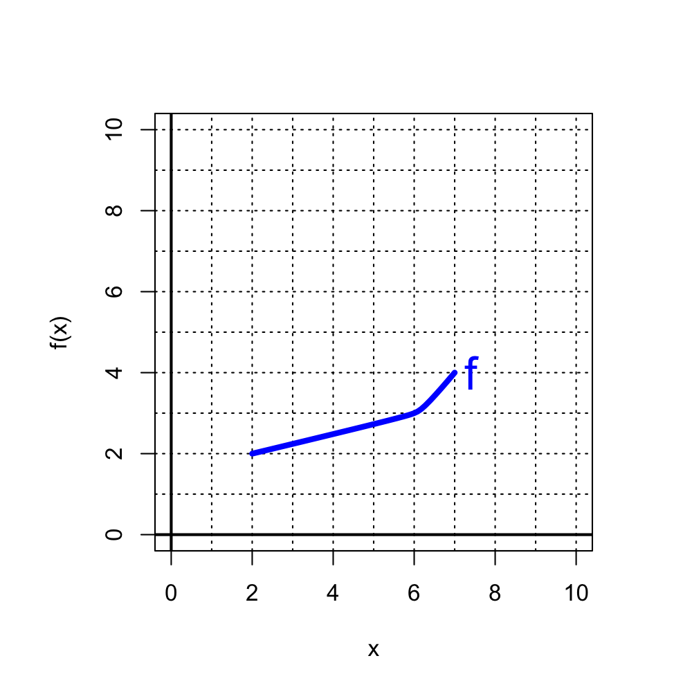

Which of the following red curves is a graph of the inverse function, $f^{-1}$?

- A

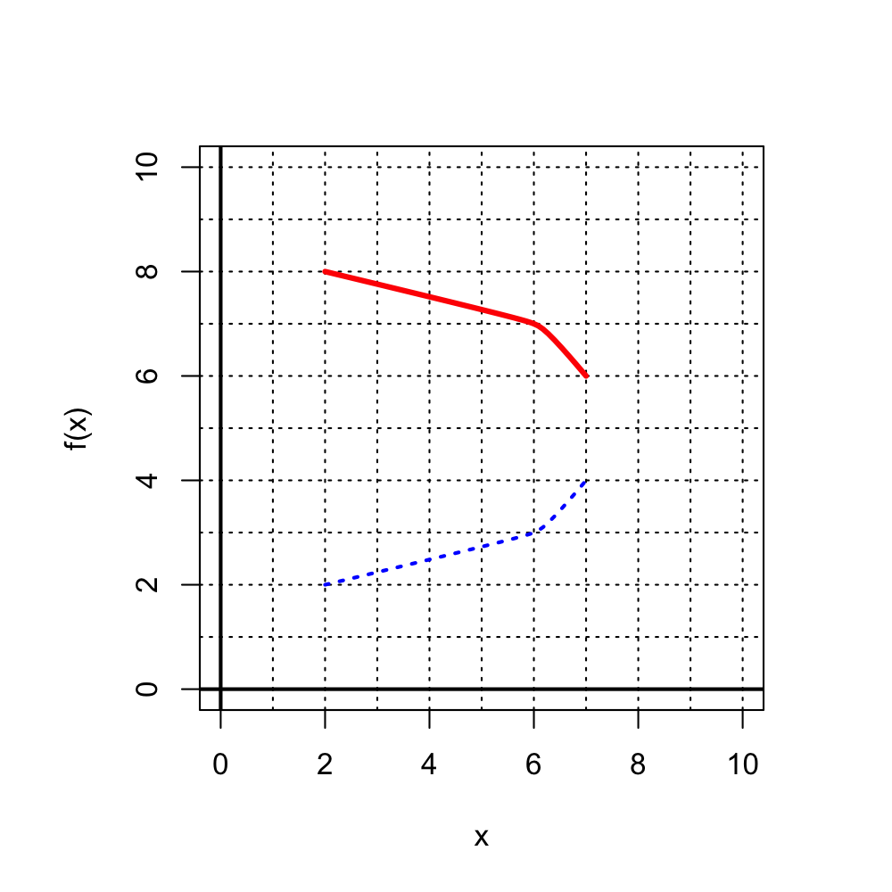

- B

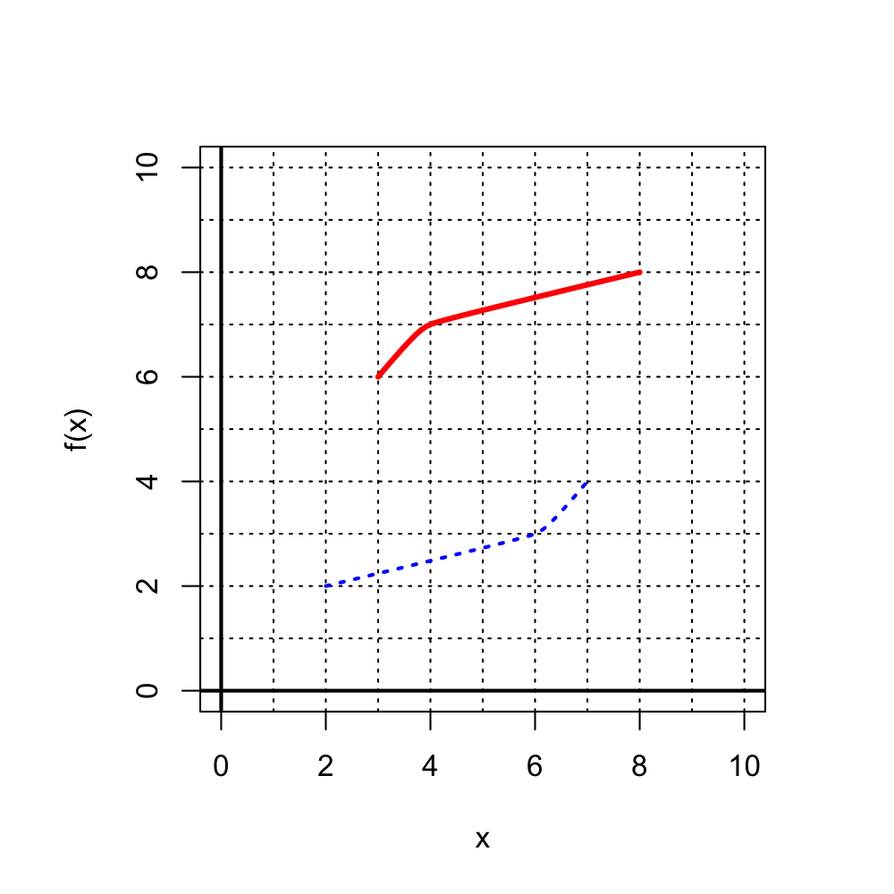

- C

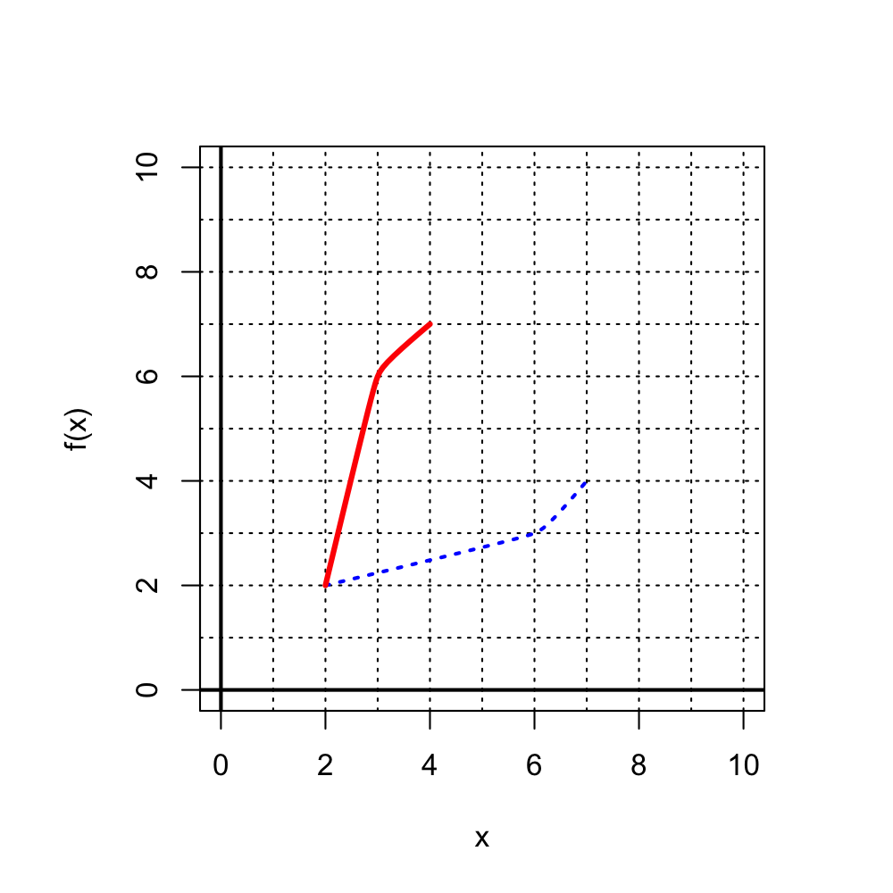

- D

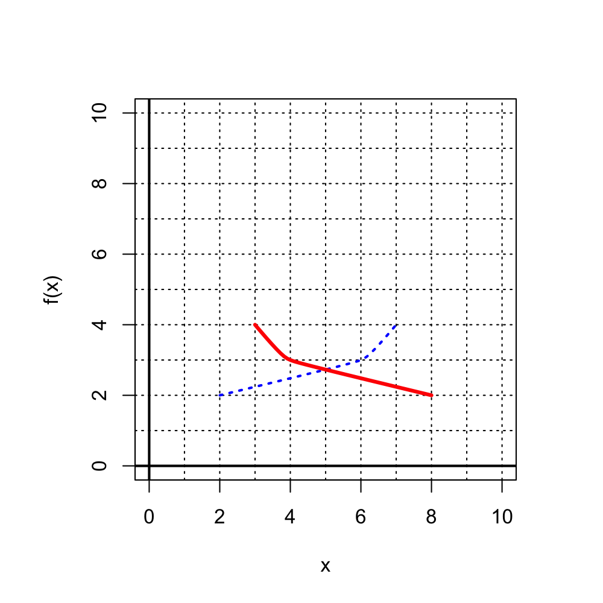

ABCD

The correct answer should have reflective symmetry across the $y=x$ line, also known as the 45$^\circ$ line.

So, the correct answer is C:

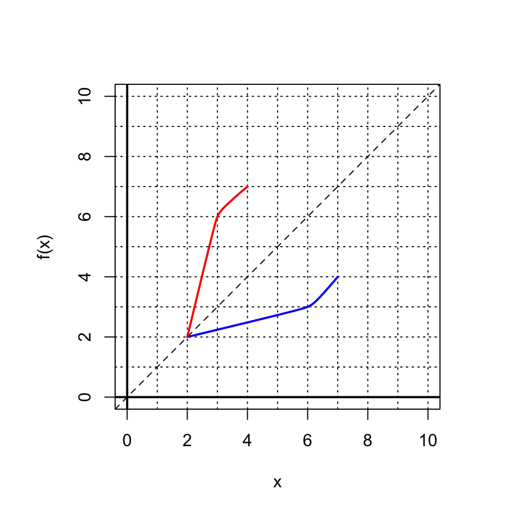

The [one-to-one](https://en.wikipedia.org/wiki/Injective_function) function $f$ is plotted below:

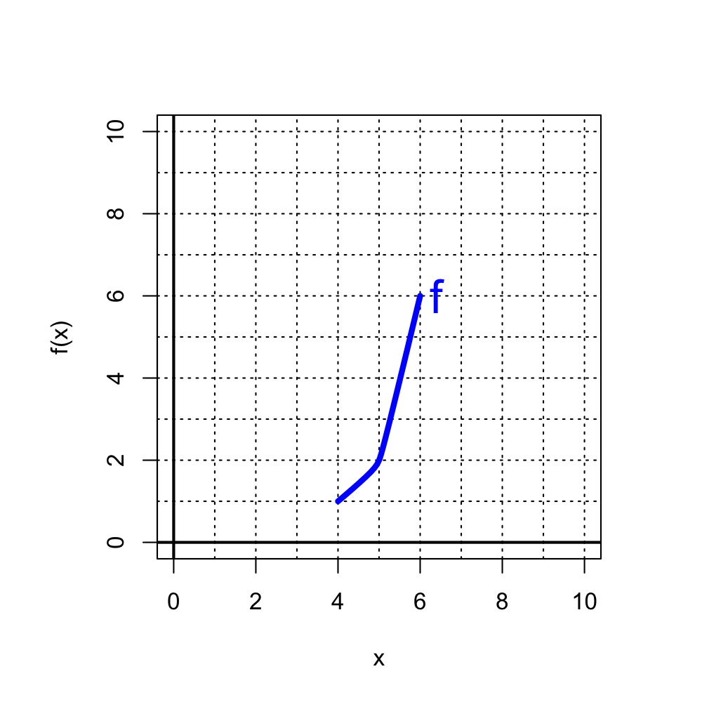

Which of the following red curves is a graph of the inverse function, $f^{-1}$?

- A

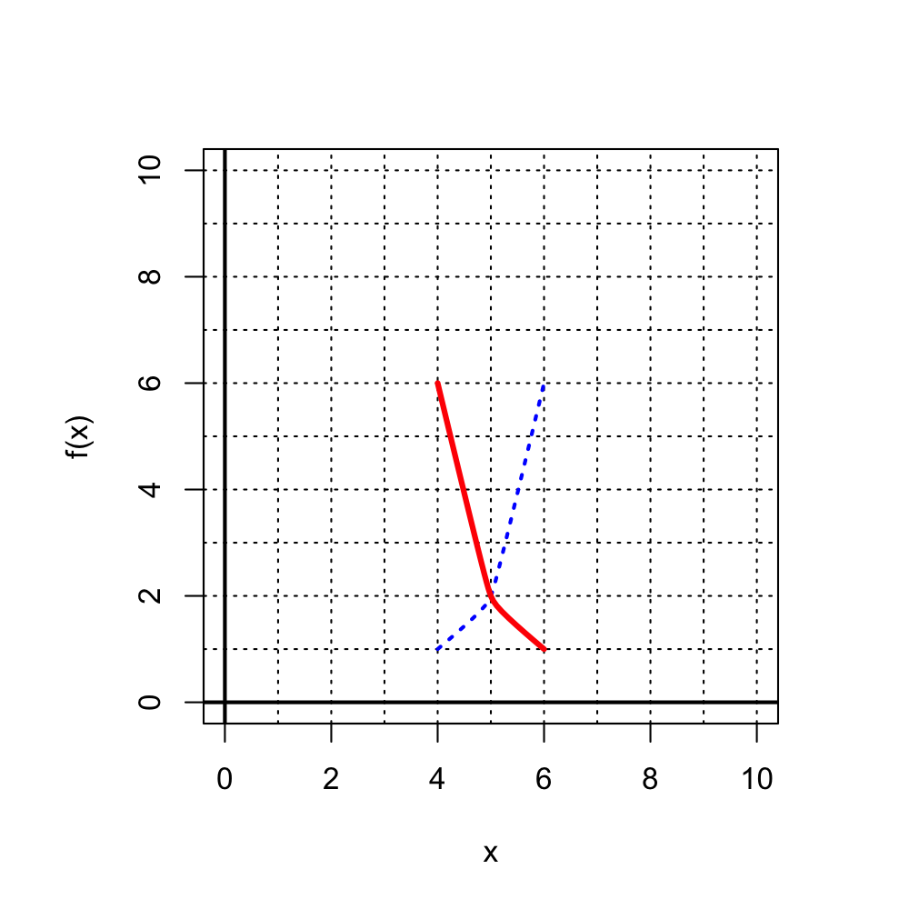

- B

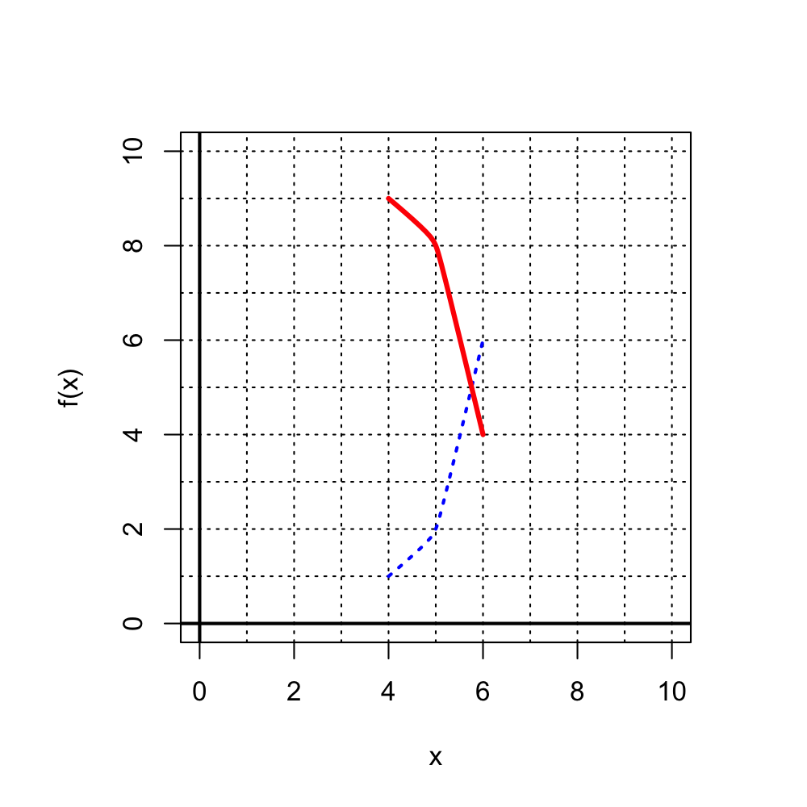

- C

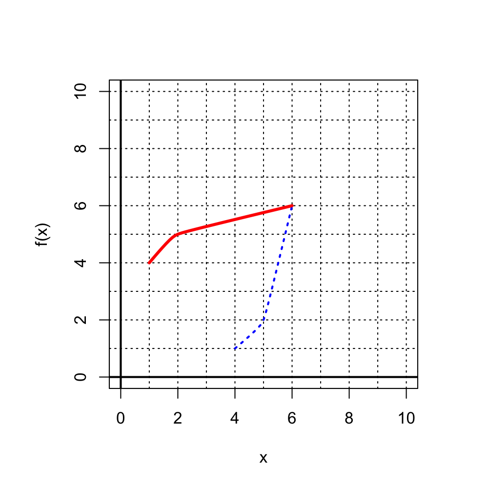

- D

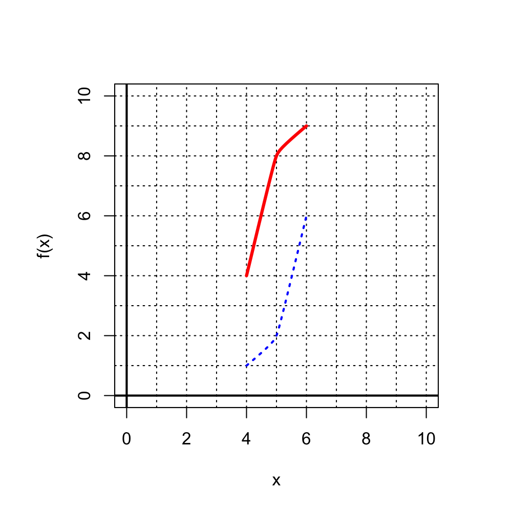

ABCD

The correct answer should have reflective symmetry across the $y=x$ line, also known as the 45$^\circ$ line.

So, the correct answer is C:

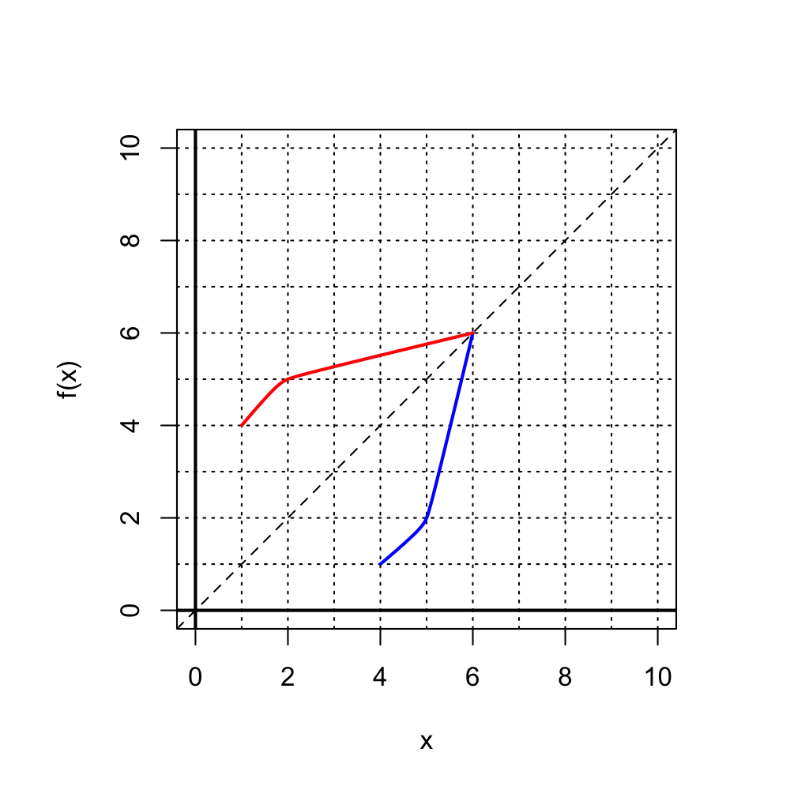

The [one-to-one](https://en.wikipedia.org/wiki/Injective_function) function $f$ is plotted below:

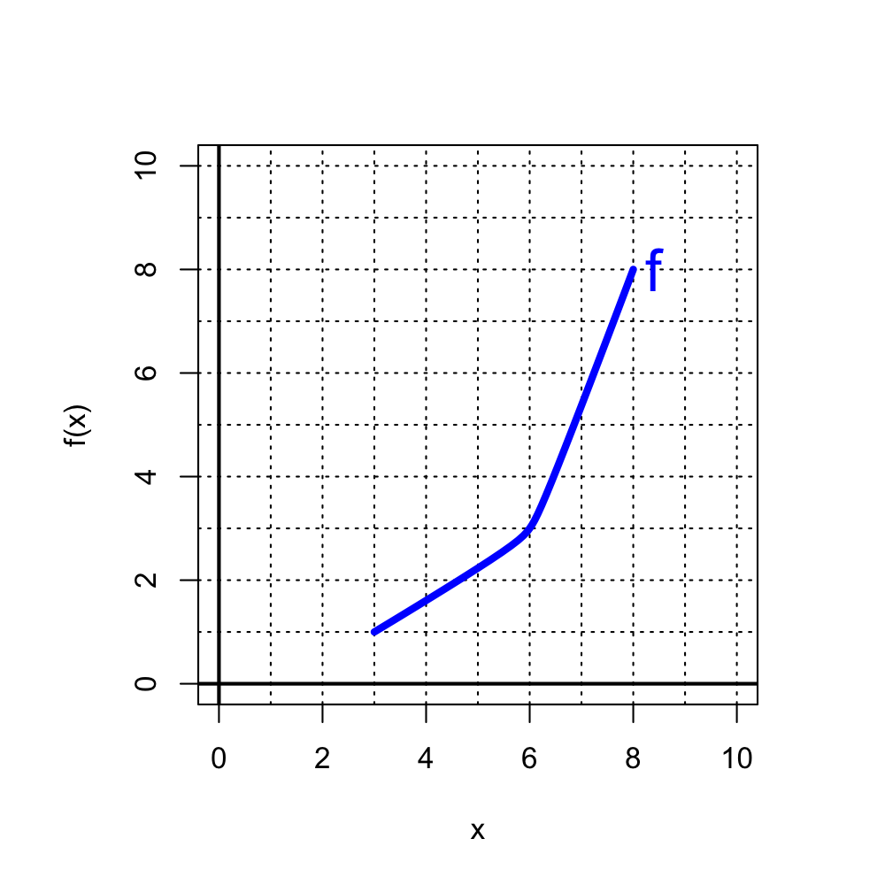

Which of the following red curves is a graph of the inverse function, $f^{-1}$?

- A

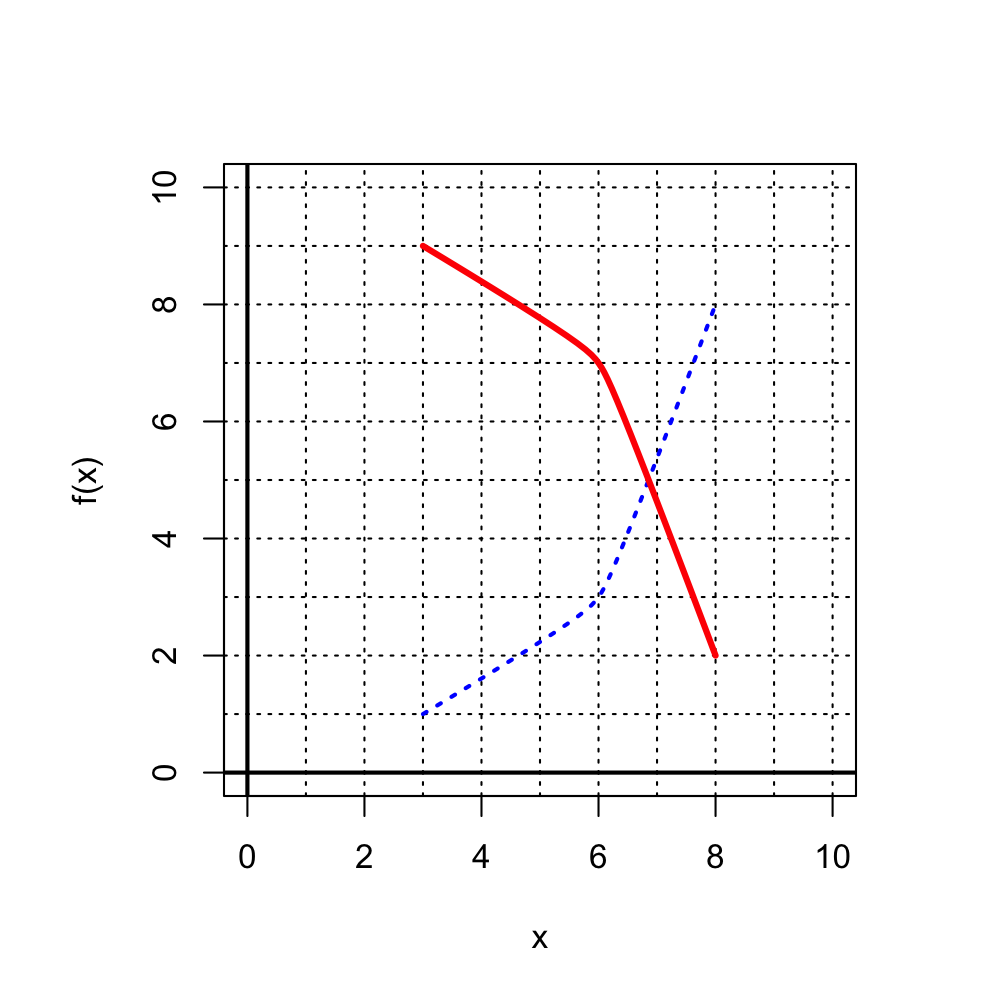

- B

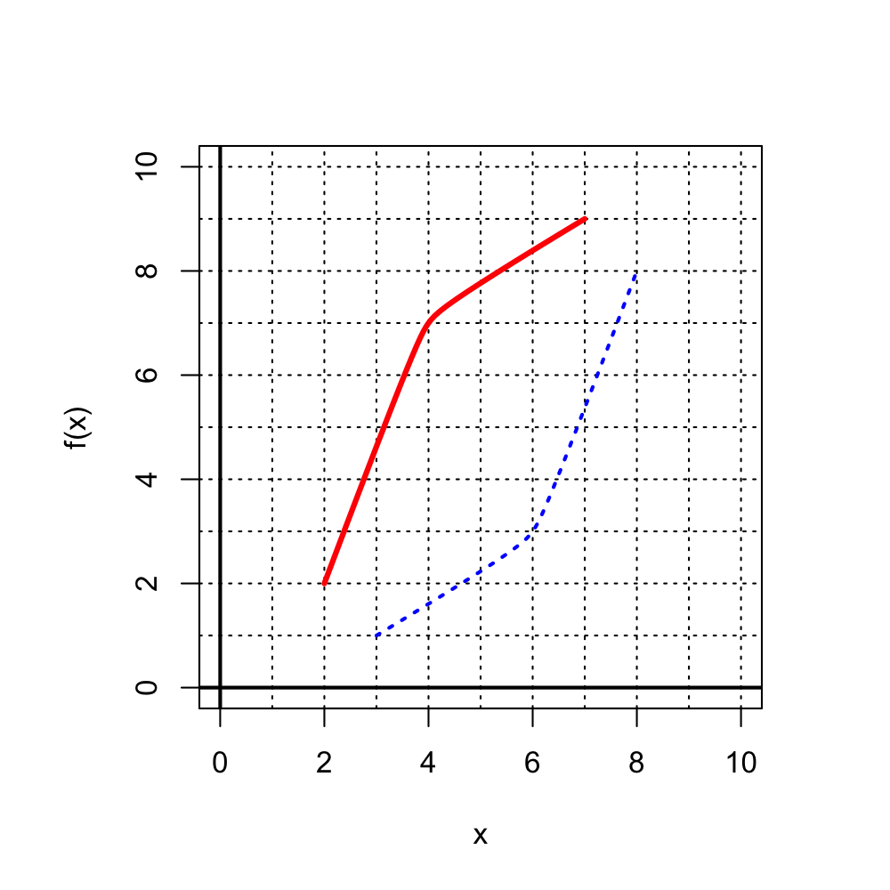

- C

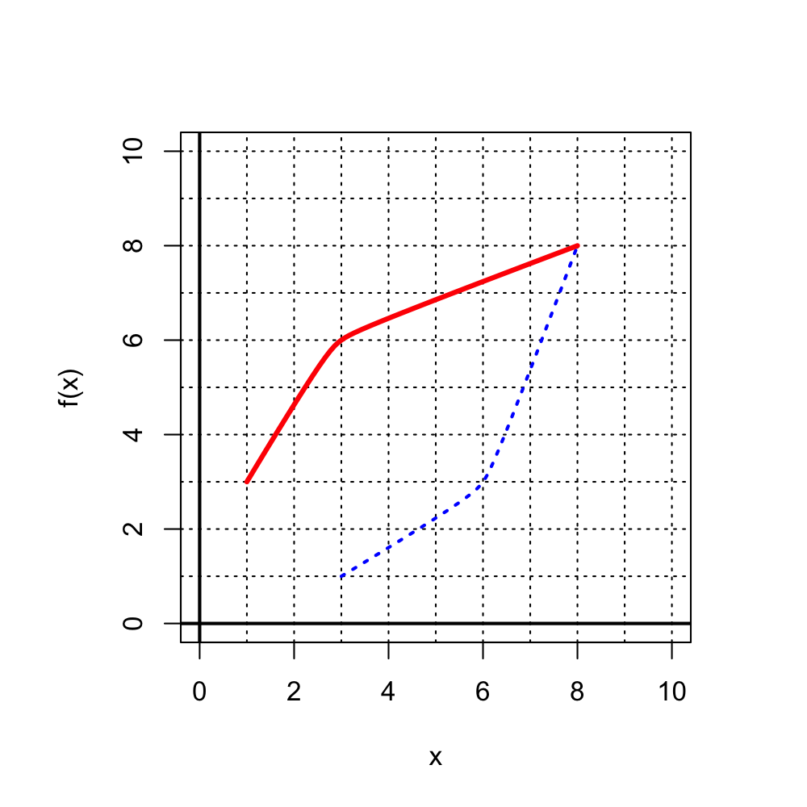

- D

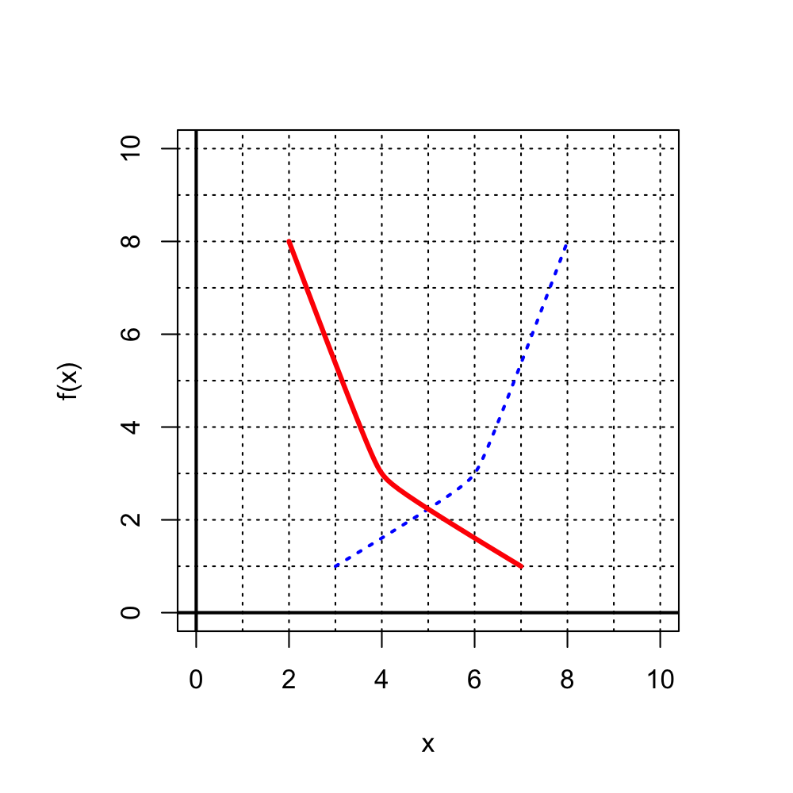

ABCD

The correct answer should have reflective symmetry across the $y=x$ line, also known as the 45$^\circ$ line.

So, the correct answer is C:

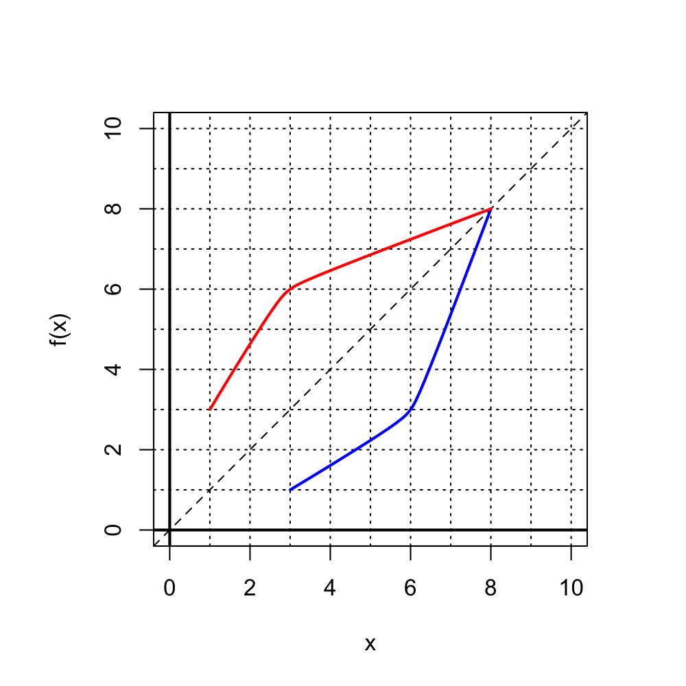

The [one-to-one](https://en.wikipedia.org/wiki/Injective_function) function $f$ is plotted below:

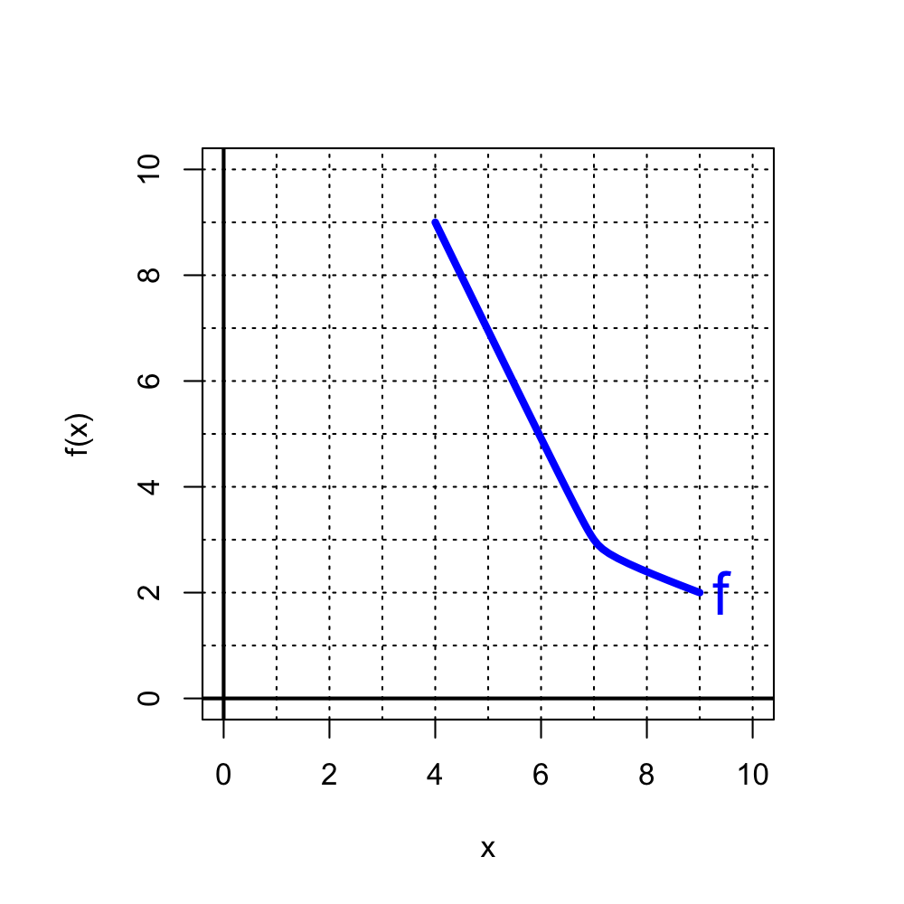

Which of the following red curves is a graph of the inverse function, $f^{-1}$?

- A

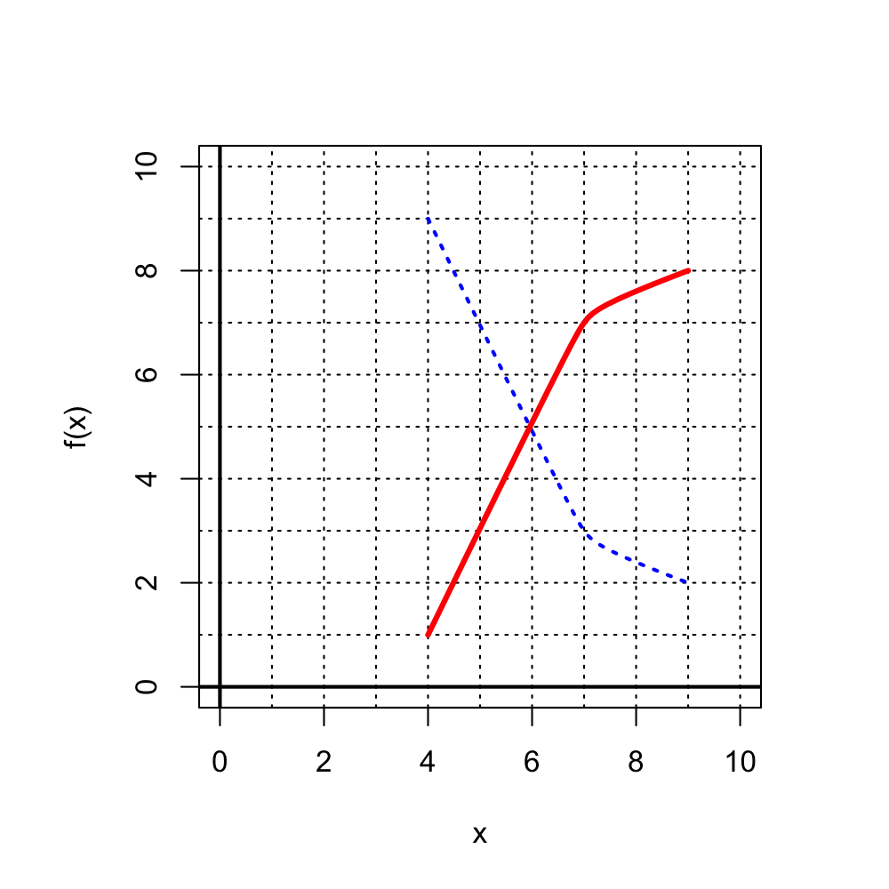

- B

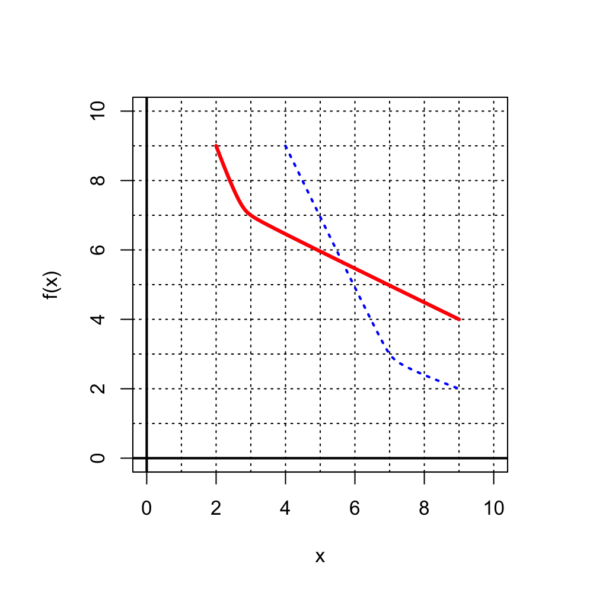

- C

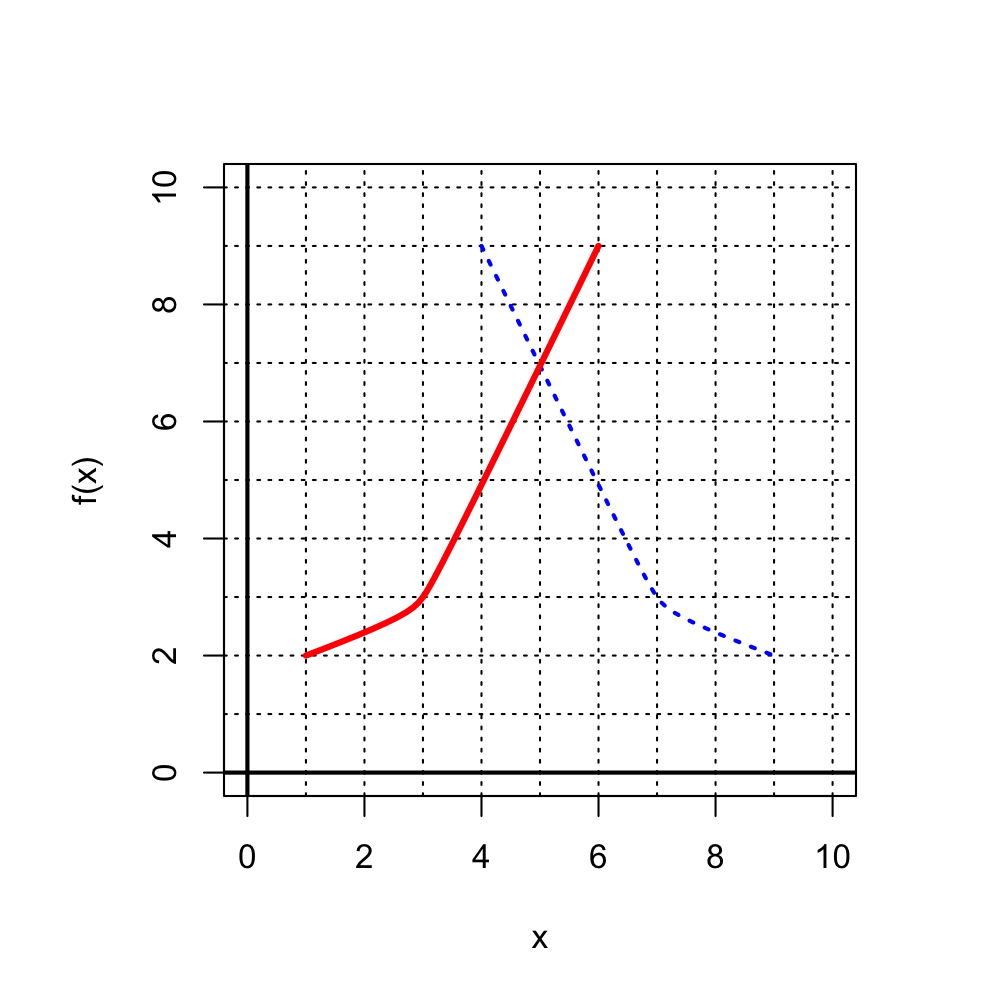

- D

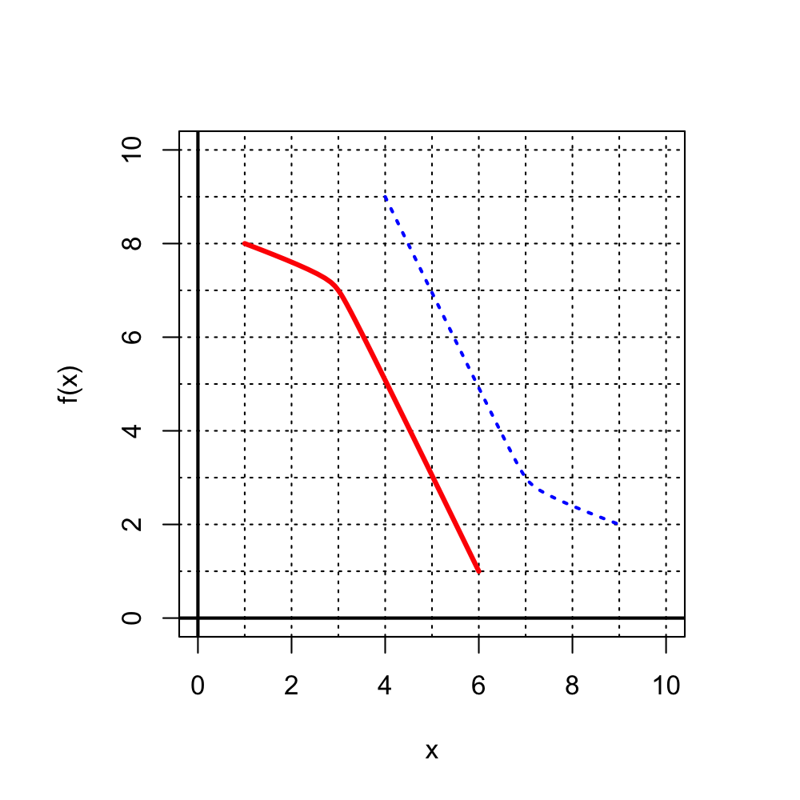

ABCD

The correct answer should have reflective symmetry across the $y=x$ line, also known as the 45$^\circ$ line.

So, the correct answer is B:

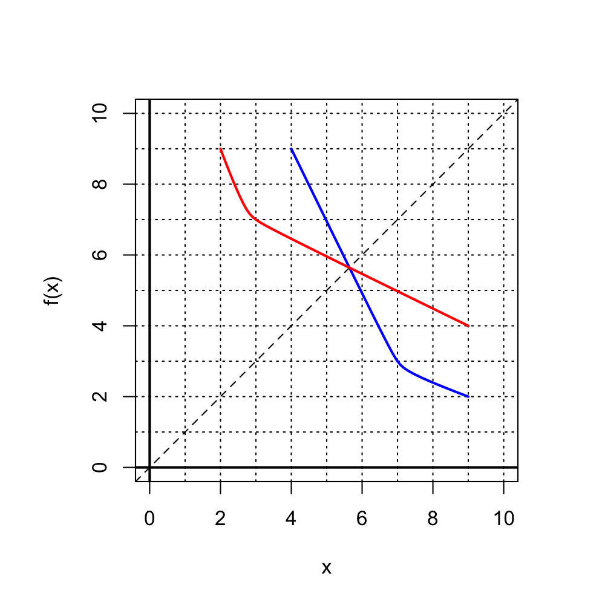

The [one-to-one](https://en.wikipedia.org/wiki/Injective_function) function $f$ is plotted below:

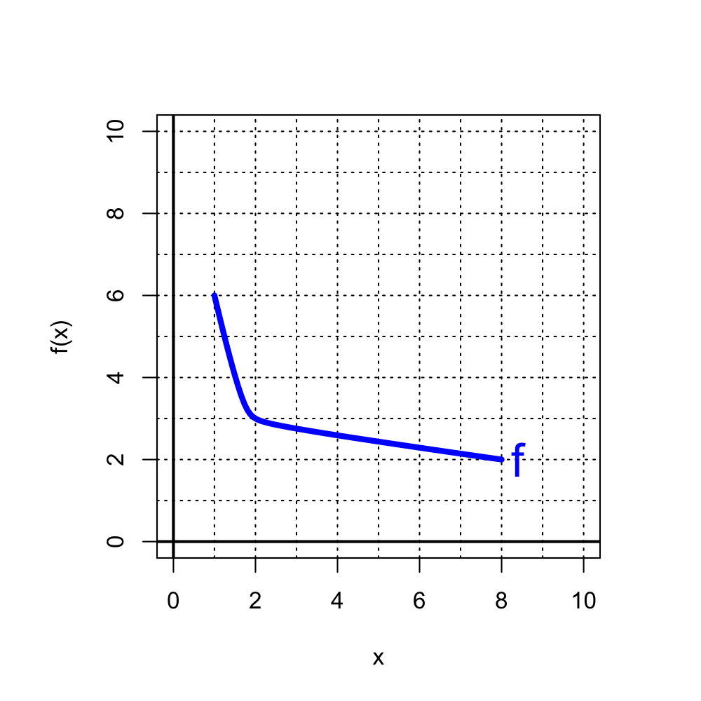

Which of the following red curves is a graph of the inverse function, $f^{-1}$?

- A

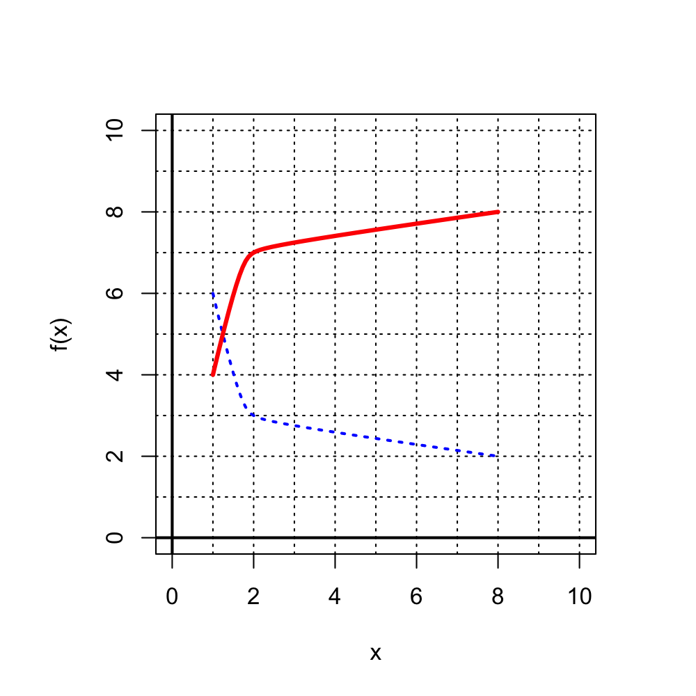

- B

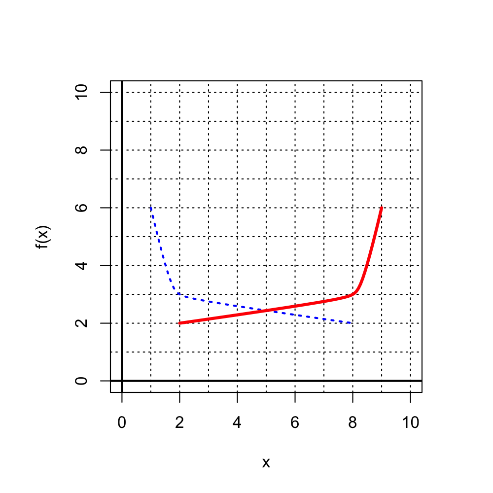

- C

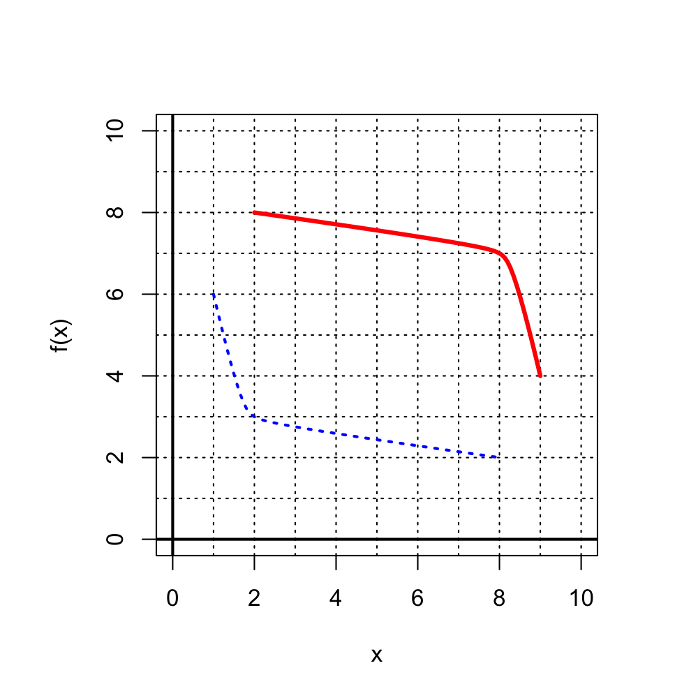

- D

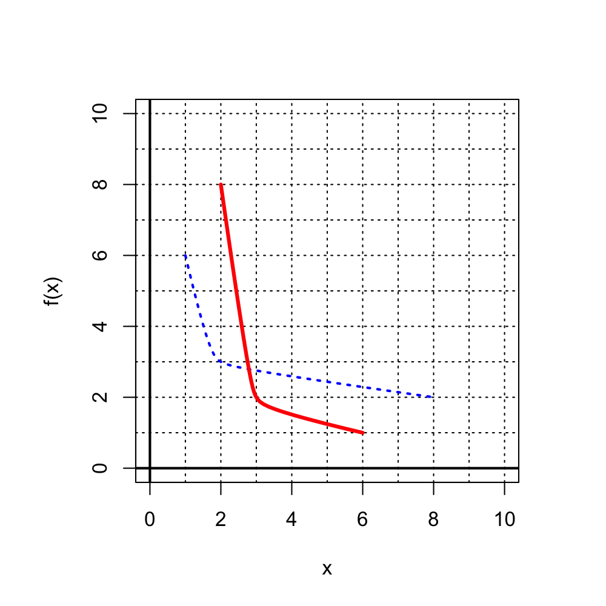

ABCD

The correct answer should have reflective symmetry across the $y=x$ line, also known as the 45$^\circ$ line.

So, the correct answer is D:

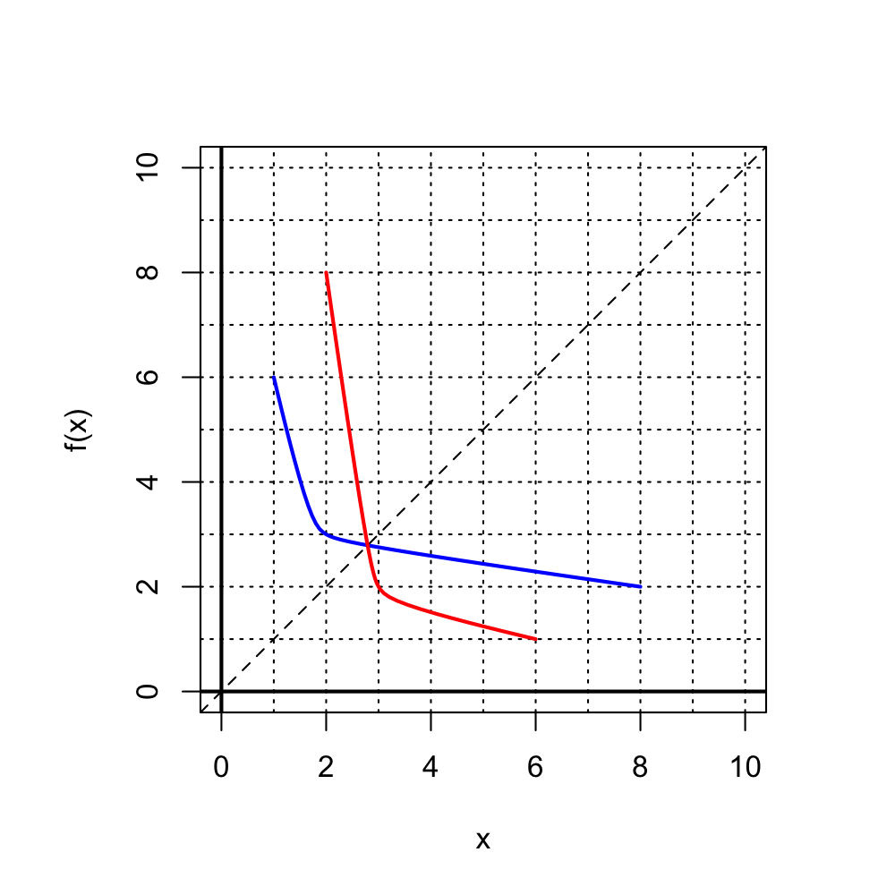

The [one-to-one](https://en.wikipedia.org/wiki/Injective_function) function $f$ is plotted below:

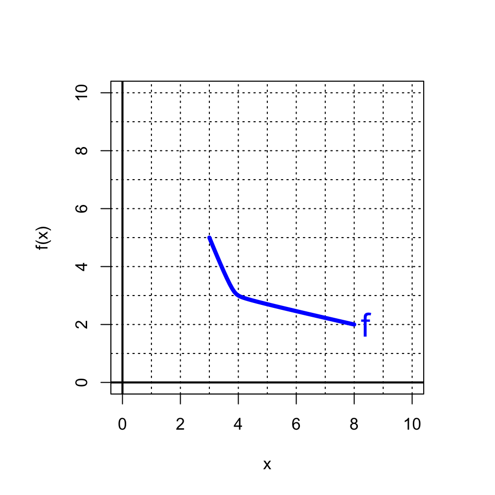

Which of the following red curves is a graph of the inverse function, $f^{-1}$?

- A

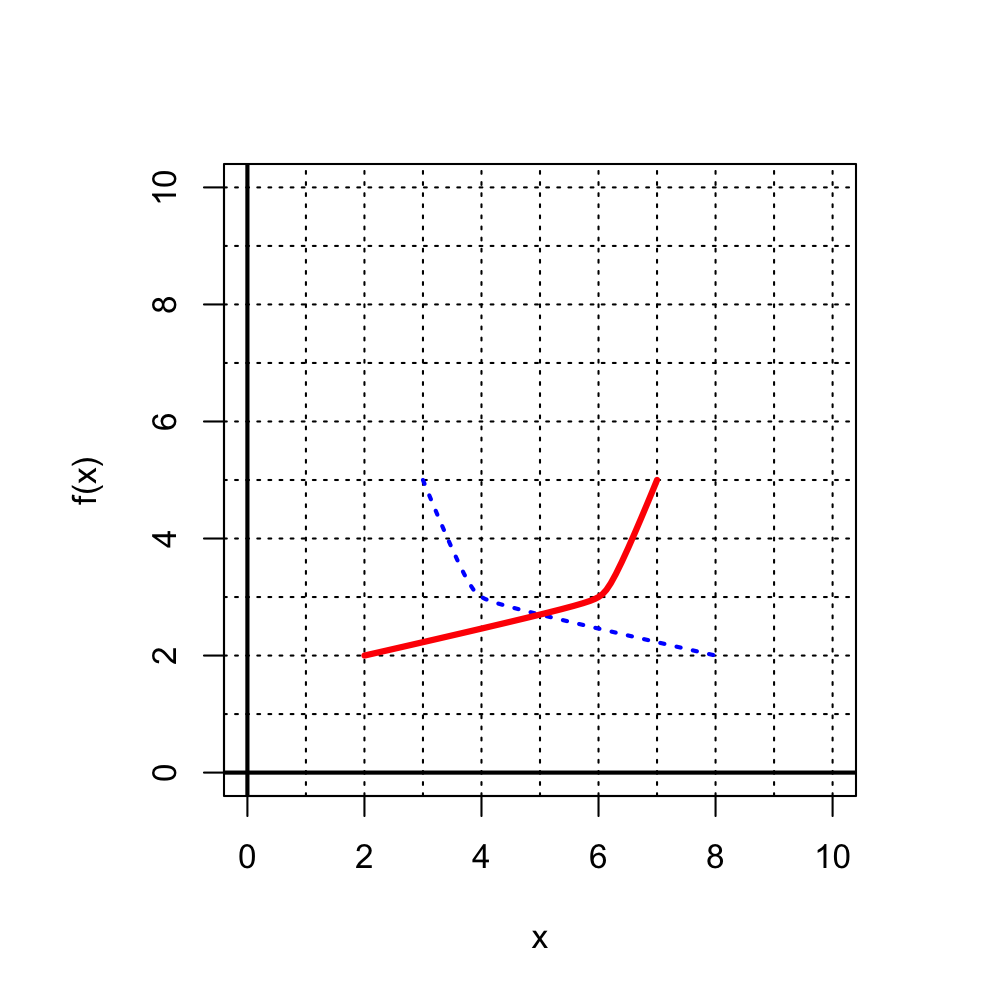

- B

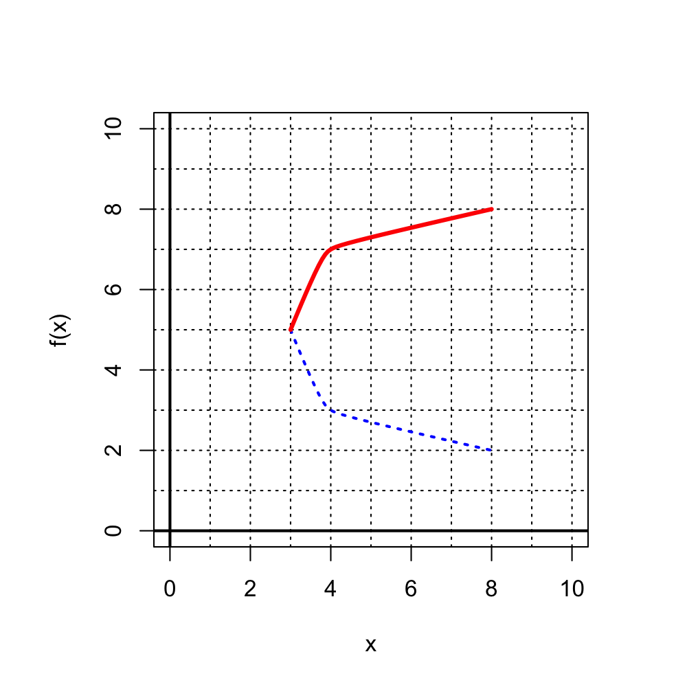

- C

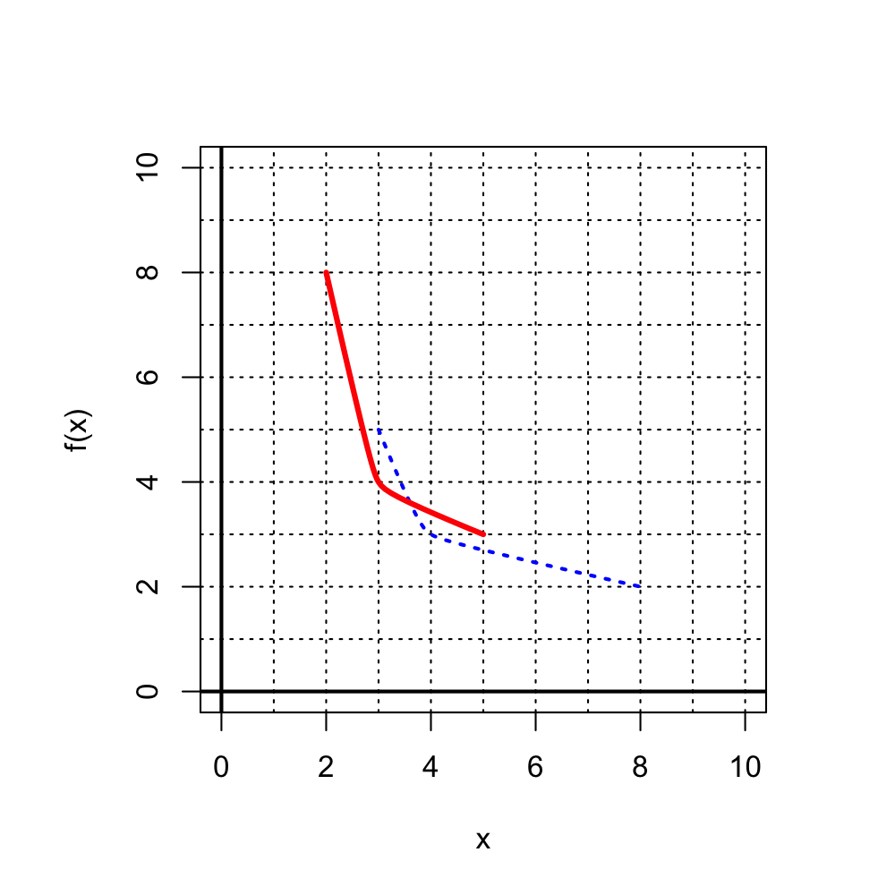

- D

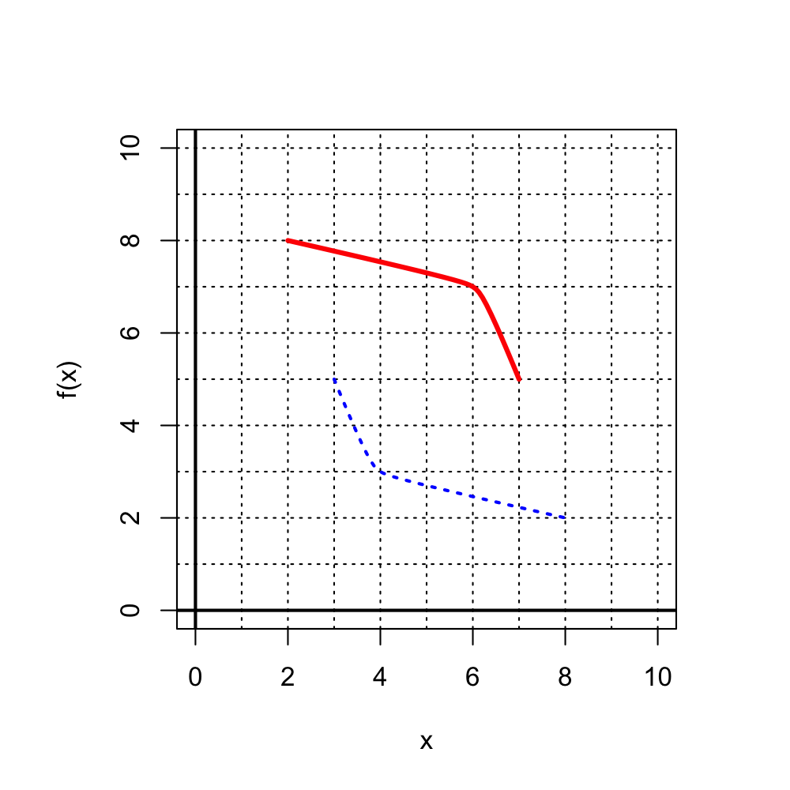

ABCD

The correct answer should have reflective symmetry across the $y=x$ line, also known as the 45$^\circ$ line.

So, the correct answer is C:

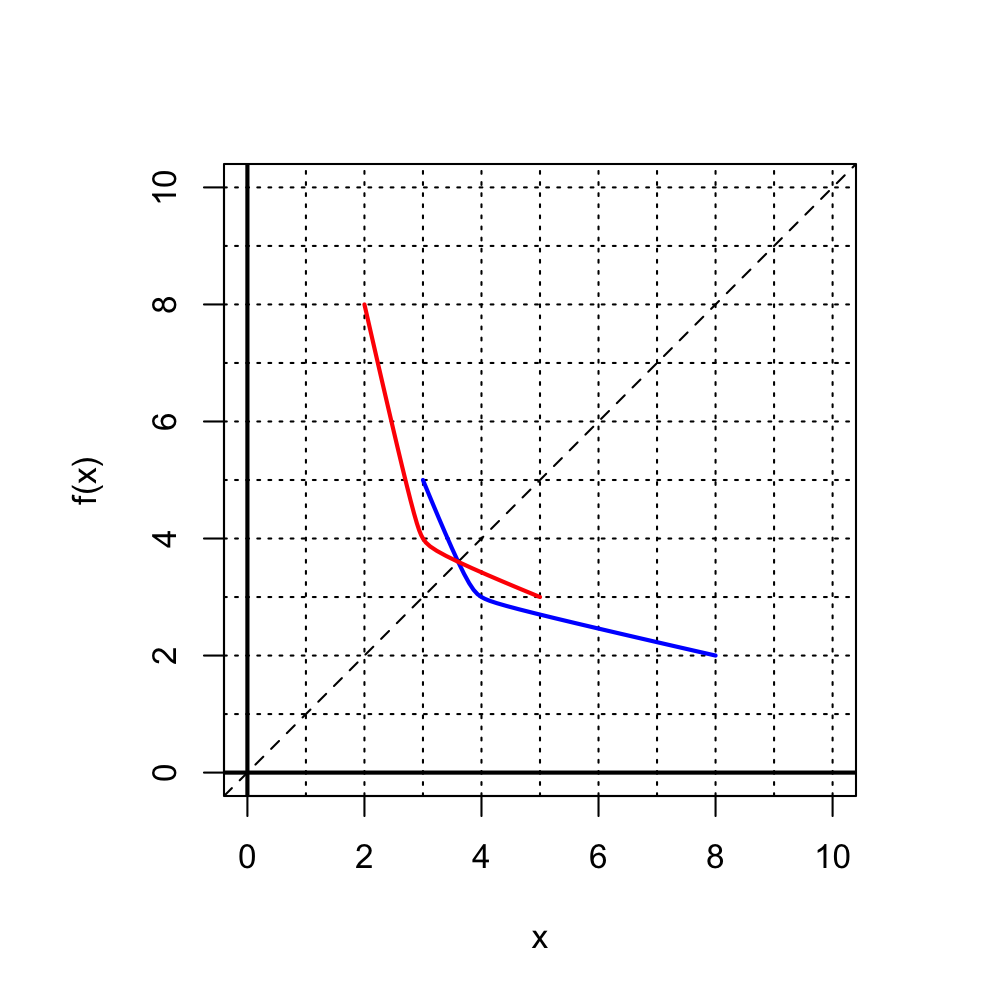

The [one-to-one](https://en.wikipedia.org/wiki/Injective_function) function $f$ is plotted below:

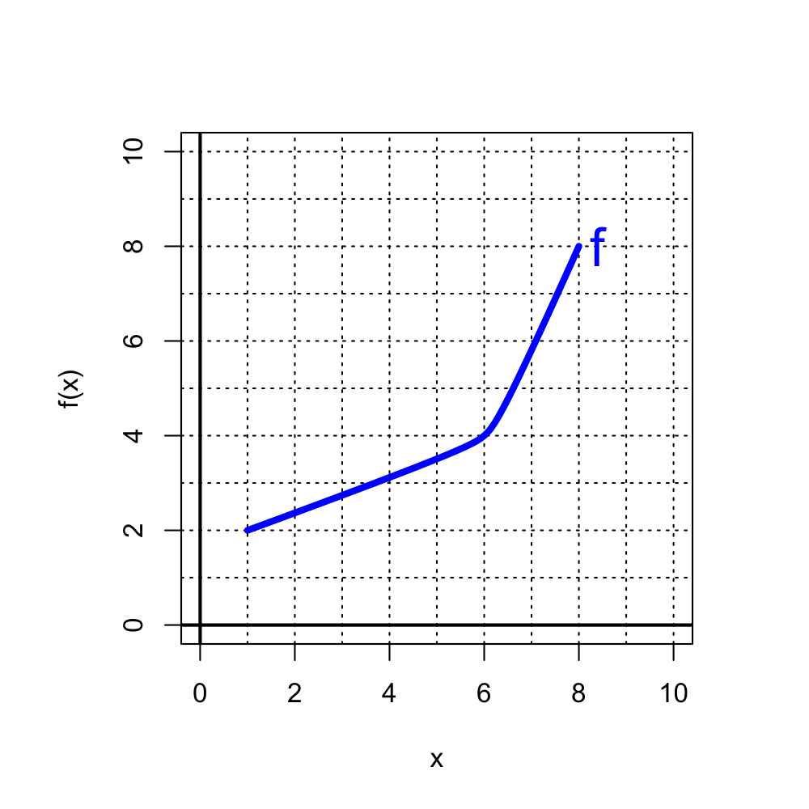

Which of the following red curves is a graph of the inverse function, $f^{-1}$?

- A

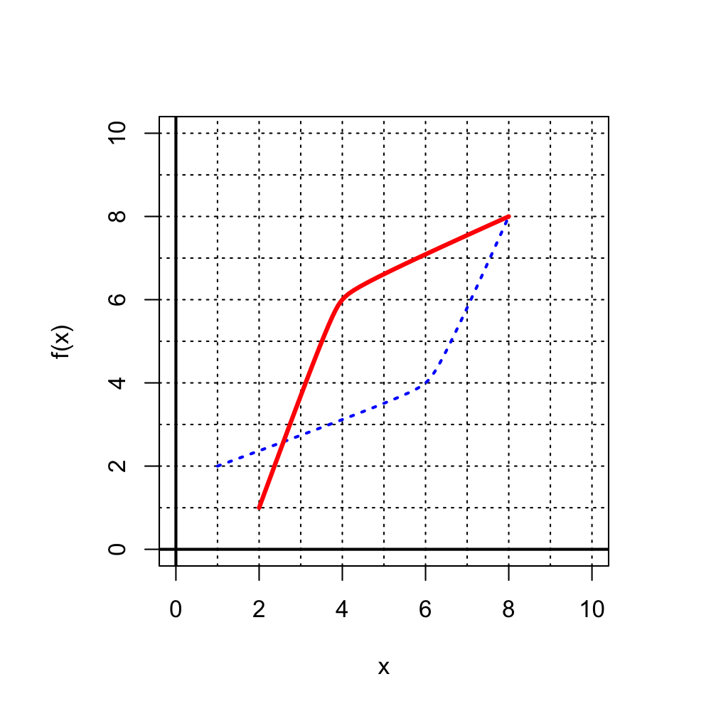

- B

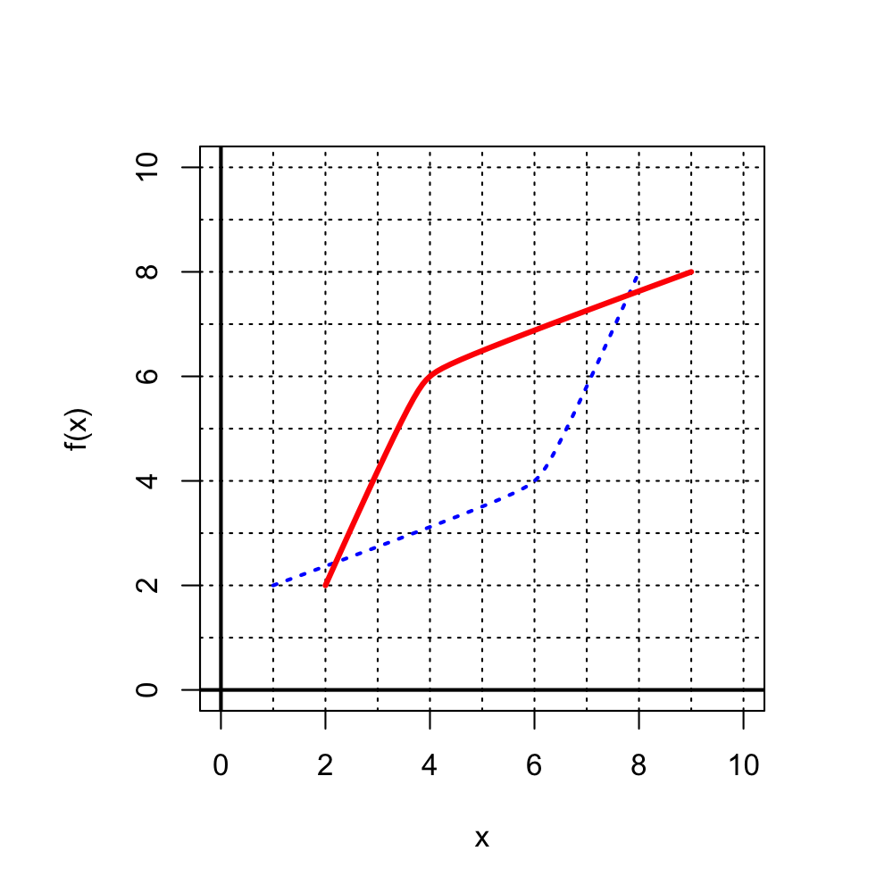

- C

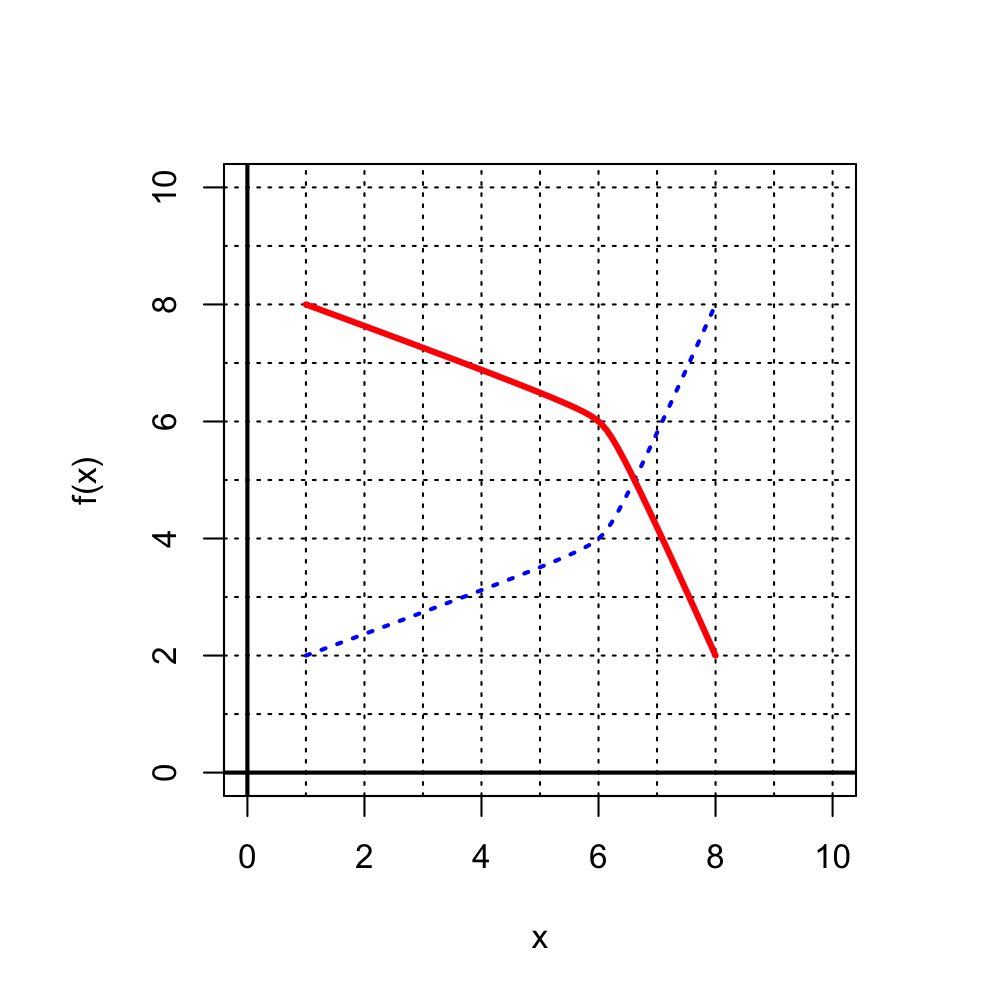

- D

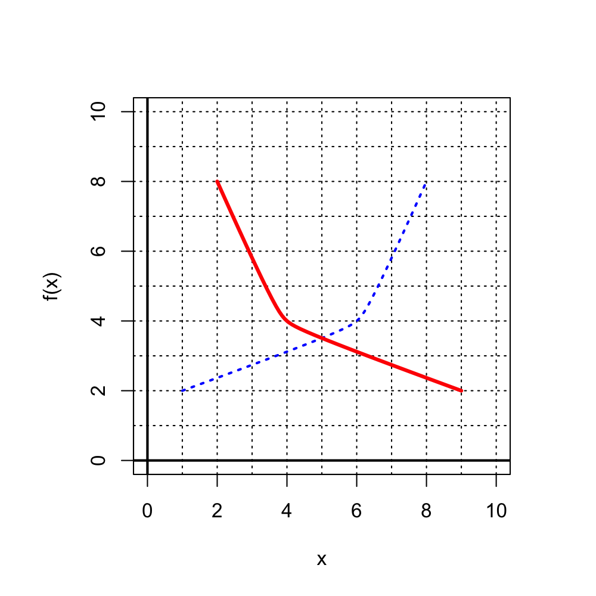

ABCD

The correct answer should have reflective symmetry across the $y=x$ line, also known as the 45$^\circ$ line.

So, the correct answer is A:

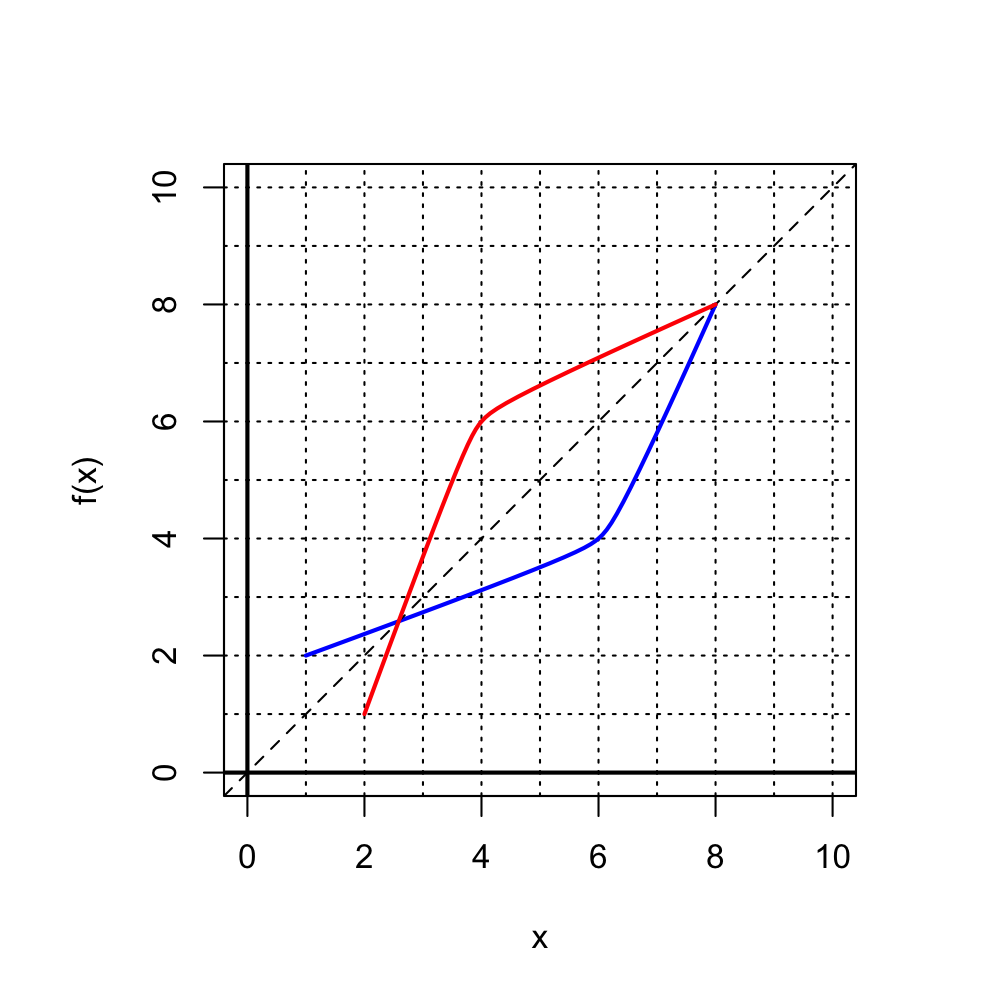

The [one-to-one](https://en.wikipedia.org/wiki/Injective_function) function $f$ is plotted below:

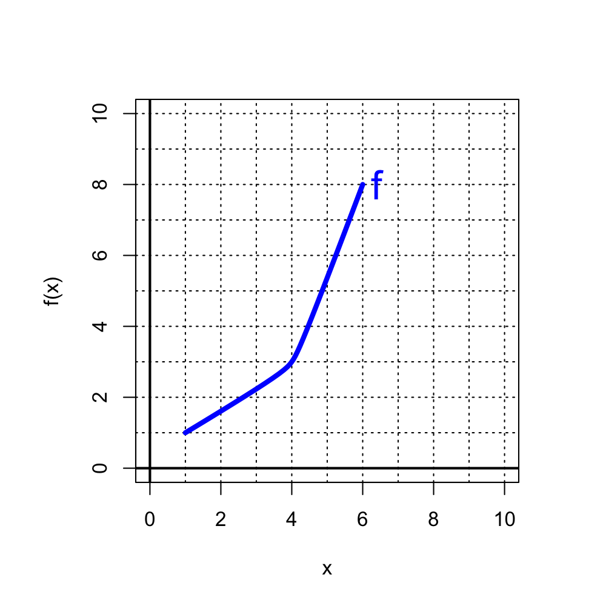